# Analysis of Power Plant 1

```python
#Importing Packages
import numpy as np
import pandas as pd
import matplotlib.pyplot as plt
import scipy
import math
import time
import seaborn as sns
sns.set_theme(style="darkgrid")
from datetime import datetime
import sklearn
from sklearn.model_selection import train_test_split
from random import randint
import keras
from keras.models import Sequential
from keras.layers import Dense, Activation
from keras import optimizers
from scikeras.wrappers import KerasClassifier, KerasRegressor
import keras.utils
import keras.layers
from sklearn.model_selection import KFold
from sklearn.model_selection import cross_val_score
from sklearn.model_selection import GridSearchCV
from sklearn.ensemble import AdaBoostClassifier, AdaBoostRegressor
import copy
import csv
from sklearn.preprocessing import MinMaxScaler

# from sklearn.neighbors import KNeighborsClassifier
# from sklearn.inspection import DecisionBoundaryDisplay
# from matplotlib import offsetbox

# from sklearn.decomposition import TruncatedSVD
# from sklearn.discriminant_analysis import LinearDiscriminantAnalysis
# from sklearn.ensemble import RandomTreesEmbedding
# from sklearn.manifold import (
#     MDS,
#     Isomap,
#     LocallyLinearEmbedding,
#     SpectralEmbedding,
# )
# from sklearn.neighbors import NeighborhoodComponentsAnalysis
# from sklearn.pipeline import make_pipeline
# from sklearn.random_projection import SparseRandomProjection

# from sklearn.metrics.pairwise import pairwise_distances
```

```python
#Import Packages
# Load Plant 1 Generation Data
plant1_gen_data = pd.read_csv('Plant_1_Generation_Data.csv')
# Load Plant 1 Weather Sensor Data
plant1_weather_data = pd.read_csv('Plant_1_Weather_Sensor_Data.csv')
```

## Pre-Processing/Cleaning Data

```python
##Remove NA's and Duplicates
plant1_gen_data = plant1_gen_data.dropna()
plant1_weather_data = plant1_weather_data.dropna()

plant1_gen_data = plant1_gen_data.drop_duplicates()
plant1_weather_data = plant1_weather_data.drop_duplicates()
```

```python
plant1_weather_data
```

|  | DATE_TIME | PLANT_ID | SOURCE_KEY | AMBIENT_TEMPERATURE | MODULE_TEMPERATURE | IRRADIATION |
| --- | --- | --- | --- | --- | --- | --- |
| 0 | 2020-05-15 00:00:00 | 4135001 | HmiyD2TTLFNqkNe | 25.184316 | 22.857507 | 0.0 |
| 1 | 2020-05-15 00:15:00 | 4135001 | HmiyD2TTLFNqkNe | 25.084589 | 22.761668 | 0.0 |
| 2 | 2020-05-15 00:30:00 | 4135001 | HmiyD2TTLFNqkNe | 24.935753 | 22.592306 | 0.0 |
| 3 | 2020-05-15 00:45:00 | 4135001 | HmiyD2TTLFNqkNe | 24.846130 | 22.360852 | 0.0 |
| 4 | 2020-05-15 01:00:00 | 4135001 | HmiyD2TTLFNqkNe | 24.621525 | 22.165423 | 0.0 |
| ... | ... | ... | ... | ... | ... | ... |
| 3177 | 2020-06-17 22:45:00 | 4135001 | HmiyD2TTLFNqkNe | 22.150570 | 21.480377 | 0.0 |
| 3178 | 2020-06-17 23:00:00 | 4135001 | HmiyD2TTLFNqkNe | 22.129816 | 21.389024 | 0.0 |
| 3179 | 2020-06-17 23:15:00 | 4135001 | HmiyD2TTLFNqkNe | 22.008275 | 20.709211 | 0.0 |
| 3180 | 2020-06-17 23:30:00 | 4135001 | HmiyD2TTLFNqkNe | 21.969495 | 20.734963 | 0.0 |
| 3181 | 2020-06-17 23:45:00 | 4135001 | HmiyD2TTLFNqkNe | 21.909288 | 20.427972 | 0.0 |

3182 rows × 6 columns

```python
#Plant 1's  data date times are different from plant 2 for some reason. Have to convert to datetime64[ns]
plant1_gen_data['DATE_TIME'] = plant1_gen_data['DATE_TIME'].astype('datetime64[ns]')
plant1_weather_data['DATE_TIME'] = plant1_weather_data['DATE_TIME'].astype('datetime64[ns]')
```

```python
#Converting Date times
plant1_gen_data['DATE_TIME'] = pd.to_datetime(plant1_gen_data['DATE_TIME'], format = '%Y-%m-%d %H:%M:%S')
plant1_weather_data['DATE_TIME'] = pd.to_datetime(plant1_weather_data['DATE_TIME'], format = '%Y-%m-%d %H:%M:%S')
```

```python
#Merge both datasets

plant1 = pd.merge(plant1_gen_data, plant1_weather_data, on='DATE_TIME')
```

```python
#Further conversion of datetime to split date and time

# adding separate time and date columns
plant1["DATE"] = pd.to_datetime(plant1["DATE_TIME"]).dt.date
plant1["TIME"] = pd.to_datetime(plant1["DATE_TIME"]).dt.time


# add hours and minutes for ml models
plant1['HOURS'] = pd.to_datetime(plant1['TIME'],format='%H:%M:%S').dt.hour
plant1['MINUTES'] = pd.to_datetime(plant1['TIME'],format='%H:%M:%S').dt.minute
plant1['TOTAL MINUTES PASS'] = plant1['MINUTES'] + plant1['HOURS']*60
plant1['MONTH'] = pd.to_datetime(plant1['TIME'], format = '%H:%M:%S').dt.month
plant1['DAY'] = pd.to_datetime(plant1['TIME'], format = '%H:%M:%S').dt.month

# add date as string column
plant1["DATE_STRING"] = plant1["DATE"].astype(str) # add column with date as string
plant1["HOURS"] = plant1["HOURS"].astype(str)
plant1["TIME"] = plant1["TIME"].astype(str)

#Convert Month, Day, Hour to int
plant1['MONTH'] = pd.to_datetime(plant1['DATE_TIME'], format = '%Y-%m-%d %H:%M:%S').dt.month
plant1['MONTH'] = plant1['MONTH'].astype('int32')
plant1['DAY'] = pd.to_datetime(plant1['DATE_TIME'], format = '%Y-%m-%d %H:%M:%S').dt.day
plant1['DAY'] = plant1['DAY'].astype('int32')
```

```python
plant1.sample(10).style.set_properties(
    **{
        'background-color': 'cyan',
        'color': 'black',
        'border-color': 'darkblack'
    })
```

|  | DATE_TIME | PLANT_ID_x | SOURCE_KEY_x | DC_POWER | AC_POWER | DAILY_YIELD | TOTAL_YIELD | PLANT_ID_y | SOURCE_KEY_y | AMBIENT_TEMPERATURE | MODULE_TEMPERATURE | IRRADIATION | DATE | TIME | HOURS | MINUTES | TOTAL MINUTES PASS | MONTH | DAY | DATE_STRING |
| --- | --- | --- | --- | --- | --- | --- | --- | --- | --- | --- | --- | --- | --- | --- | --- | --- | --- | --- | --- | --- |
| 57514 | 2020-06-12 15:30:00 | 4135001 | McdE0feGgRqW7Ca | 5915.428571 | 579.657143 | 5275.857143 | 7372648.857000 | 4135001 | HmiyD2TTLFNqkNe | 27.853870 | 36.612921 | 0.399854 | 2020-06-12 | 15:30:00 | 15 | 30 | 930 | 6 | 12 | 2020-06-12 |
| 41499 | 2020-06-05 00:30:00 | 4135001 | 1IF53ai7Xc0U56Y | 0.000000 | 0.000000 | 0.000000 | 6340855.000000 | 4135001 | HmiyD2TTLFNqkNe | 22.451550 | 20.014420 | 0.000000 | 2020-06-05 | 00:30:00 | 0 | 30 | 30 | 6 | 5 | 2020-06-05 |
| 36999 | 2020-06-02 20:15:00 | 4135001 | uHbuxQJl8lW7ozc | 0.000000 | 0.000000 | 7463.000000 | 7178405.000000 | 4135001 | HmiyD2TTLFNqkNe | 23.695445 | 21.070044 | 0.000000 | 2020-06-02 | 20:15:00 | 20 | 15 | 1215 | 6 | 2 | 2020-06-02 |
| 57326 | 2020-06-12 13:15:00 | 4135001 | pkci93gMrogZuBj | 7767.000000 | 760.328571 | 3596.571429 | 7378552.571000 | 4135001 | HmiyD2TTLFNqkNe | 27.474866 | 42.547817 | 0.536697 | 2020-06-12 | 13:15:00 | 13 | 15 | 795 | 6 | 12 | 2020-06-12 |
| 36607 | 2020-06-02 15:30:00 | 4135001 | z9Y9gH1T5YWrNuG | 6041.857143 | 592.000000 | 6532.428571 | 7146360.429000 | 4135001 | HmiyD2TTLFNqkNe | 26.279598 | 36.349589 | 0.402698 | 2020-06-02 | 15:30:00 | 15 | 30 | 930 | 6 | 2 | 2020-06-02 |
| 10452 | 2020-05-20 03:45:00 | 4135001 | zBIq5rxdHJRwDNY | 0.000000 | 0.000000 | 0.000000 | 6371971.000000 | 4135001 | HmiyD2TTLFNqkNe | 22.108852 | 19.497703 | 0.000000 | 2020-05-20 | 03:45:00 | 3 | 45 | 225 | 5 | 20 | 2020-05-20 |
| 17214 | 2020-05-24 00:45:00 | 4135001 | zBIq5rxdHJRwDNY | 0.000000 | 0.000000 | 0.000000 | 6404481.000000 | 4135001 | HmiyD2TTLFNqkNe | 24.253961 | 21.661316 | 0.000000 | 2020-05-24 | 00:45:00 | 0 | 45 | 45 | 5 | 24 | 2020-05-24 |
| 21629 | 2020-05-26 03:30:00 | 4135001 | zVJPv84UY57bAof | 0.000000 | 0.000000 | 0.000000 | 7197609.000000 | 4135001 | HmiyD2TTLFNqkNe | 21.379244 | 19.249369 | 0.000000 | 2020-05-26 | 03:30:00 | 3 | 30 | 210 | 5 | 26 | 2020-05-26 |
| 12900 | 2020-05-21 21:15:00 | 4135001 | 1BY6WEcLGh8j5v7 | 0.000000 | 0.000000 | 7243.000000 | 6305589.000000 | 4135001 | HmiyD2TTLFNqkNe | 24.478779 | 22.165891 | 0.000000 | 2020-05-21 | 21:15:00 | 21 | 15 | 1275 | 5 | 21 | 2020-05-21 |
| 7992 | 2020-05-18 22:30:00 | 4135001 | iCRJl6heRkivqQ3 | 0.000000 | 0.000000 | 5400.000000 | 7203767.000000 | 4135001 | HmiyD2TTLFNqkNe | 22.850214 | 20.732054 | 0.000000 | 2020-05-18 | 22:30:00 | 22 | 30 | 1350 | 5 | 18 | 2020-05-18 |

## Data Visualization

We first observe the summary statistics of power plant 1.

```python
#Describe is basically R's Summarize function from dplyr. Use it to look at statistics of each column
plant1.drop(['DATE_TIME', 'PLANT_ID_x','PLANT_ID_y'], axis = 1).describe().style.background_gradient(cmap='Purples')
```

|  | DC_POWER | AC_POWER | DAILY_YIELD | TOTAL_YIELD | AMBIENT_TEMPERATURE | MODULE_TEMPERATURE | IRRADIATION | MINUTES | TOTAL MINUTES PASS | MONTH | DAY |
| --- | --- | --- | --- | --- | --- | --- | --- | --- | --- | --- | --- |
| count | 68774.000000 | 68774.000000 | 68774.000000 | 68774.000000 | 68774.000000 | 68774.000000 | 68774.000000 | 68774.000000 | 68774.000000 | 68774.000000 | 68774.000000 |
| mean | 3147.177450 | 307.778375 | 3295.834644 | 6978727.511362 | 25.558521 | 31.244997 | 0.232305 | 22.490621 | 716.515107 | 5.518539 | 15.762876 |
| std | 4036.441826 | 394.394865 | 3145.220597 | 416270.720885 | 3.361300 | 12.308283 | 0.301948 | 16.772385 | 412.069969 | 0.499660 | 8.554460 |
| min | 0.000000 | 0.000000 | 0.000000 | 6183645.000000 | 20.398505 | 18.140415 | 0.000000 | 0.000000 | 0.000000 | 5.000000 | 1.000000 |
| 25% | 0.000000 | 0.000000 | 0.000000 | 6512006.826000 | 22.724491 | 21.123944 | 0.000000 | 0.000000 | 360.000000 | 5.000000 | 9.000000 |
| 50% | 428.571429 | 41.450000 | 2658.473214 | 7146685.000000 | 24.670178 | 24.818984 | 0.031620 | 15.000000 | 720.000000 | 6.000000 | 16.000000 |
| 75% | 6365.468750 | 623.561161 | 6274.000000 | 7268751.397000 | 27.960429 | 41.693659 | 0.454880 | 30.000000 | 1065.000000 | 6.000000 | 23.000000 |
| max | 14471.125000 | 1410.950000 | 9163.000000 | 7846821.000000 | 35.252486 | 65.545714 | 1.221652 | 45.000000 | 1425.000000 | 6.000000 | 31.000000 |

### Time vs Power Generation

We now plot their generation with respect to time.

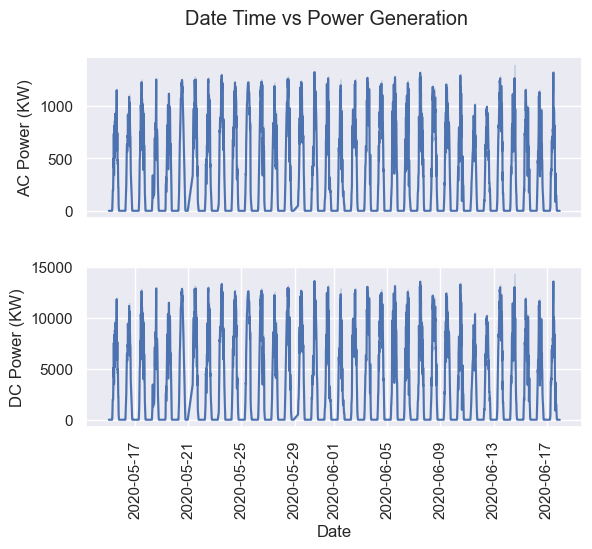

```python
import warnings
#This temporarily disables warnings. We put the first two lines of code below to disable warnings, then put
#the rest of the code inside that contains the warnings from the library
with warnings.catch_warnings():
    warnings.simplefilter('ignore')
    fig, axes = plt.subplots(2)
    sns.lineplot(data = plant1, x ='DATE_TIME', y = 'AC_POWER', ax = axes[0])
    sns.lineplot(data = plant1, x ='DATE_TIME', y = 'DC_POWER', ax = axes[1])
    plt.subplots_adjust(hspace=0.3)

    #Remove "1e9" from the top left of graph
    axes[0].yaxis.offsetText.set_visible(False)
    axes[1].yaxis.offsetText.set_visible(False)
    axes[0].set_ylabel("AC Power (KW)")
    axes[1].set_ylabel("DC Power (KW)")
    axes[0].tick_params(axis='x',
        which='both',
        bottom=False,
        top=False,
        labelbottom=False)
    axes[1].set_xlabel("Date")
    axes[0].get_xaxis().set_visible(False)
    #Rotate ticks
    axes[1].tick_params(axis='x', labelrotation=90)

    fig.suptitle('Date Time vs Power Generation');
```

We see an oscillatory nature between date time and power generation. Since this is a solar power plant, weather plays a big role in the amount of energy generated.

### Time vs Energy Generated per date

We take a look at the relationship between time and energy generated, per date.

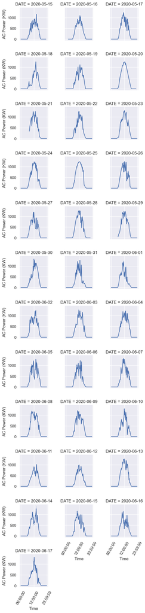

```python
#Disable warnings
with warnings.catch_warnings():
    warnings.simplefilter('ignore')
    g = sns.FacetGrid(plant1, col="DATE", col_wrap=3, height=2)
    g.map(sns.lineplot, 'TIME', 'AC_POWER')
    g.set_axis_labels("Time", "AC Power (KW)")
    g.set(xticks=['00:00:00', '12:00:00', '23:59:59'])
    for ax in g.axes:
        for label in ax.get_xticklabels():
            label.set_rotation(60);
```

As shown above, the time of day is important when generating electricity because the sun is up during the daytime, so we can see how production is maximized in this time. Other important factors regarding weather include whether it is cloudy, rainy, snowy, etc., as clouds can obstruct sunlight. Note that the plants appear to start around 6 AM and end around 7 PM.

#### DC to AC power Relationship

We then determine how different the energy production is for AC power vs DC power. In theory, they should be very close to identical ($y=x$) because DC power is converted to AC power. It seems that there is an error with the dataset: Most efficiencies for dc to ac conversion should be around .8 to 1. In fact, this is the case for plant 2. But for plant 1, the ac output is usually about 10% the output for dc output. This might be an error (Testing this on an experimental notebook, it turns out the DC Power Output for plant 1 is 10 % the DC Power Output for plant 2, which does not make since because the AC power output for both plants are relatively stable). Hence we revise this by dividing plant 1's output by 10.

```python
plant1['DC_POWER'] = plant1['DC_POWER'] / 10
```

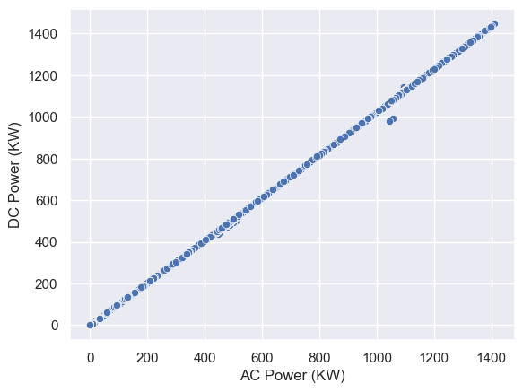

```python
fig, axes = plt.subplots()
sns.scatterplot(data = plant1, x = 'AC_POWER', y = 'DC_POWER')
axes.set_xlabel('AC Power (KW)')
axes.set_ylabel('DC Power (KW)');
```

To identify possible features for predicting AC Power output, we focus on seeing on how much each factor in the data set influences AC Power.

### Temperature vs AC Power

Since we don't have direct weather data, we instead look at temperature data, and assessing their relationship with AC Power generation.

```
Ambient Temperature vs AC Power r coefficient:  0.7249025237604686
Module Temperature vs AC Power r coefficient:  0.954924343080112
```

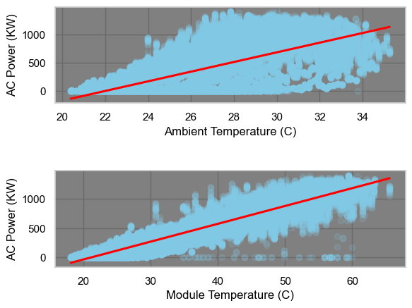

```python
#Ambient Temperature vs DC Power
custom_style = {'axes.labelcolor': 'black',
                'xtick.color': 'black',
                'ytick.color': 'black',
               'axes.facecolor': 'gray',
               'grid.color': 'dimgray'}
#Completely replace the "whitegrid" seaborn style with my new custom style
#My custom style is my attempt to recreate the "theme_dark" style from ggplot2 in R
sns.set_style("whitegrid", rc=custom_style)
fig, axes = plt.subplots(2)
plt.subplots_adjust(hspace=0.7)
sns.regplot(data = plant1, x = 'AMBIENT_TEMPERATURE', y = 'AC_POWER',scatter_kws={'alpha':0.15, 'color' : 'skyblue'}, line_kws={'color': 'red'}, ax = axes[0])
sns.regplot(data = plant1, x = 'MODULE_TEMPERATURE', y = 'AC_POWER',scatter_kws={'alpha':0.15, 'color' : 'skyblue'}, line_kws={'color': 'red'}, ax = axes[1])
axes[0].set_xlabel('Ambient Temperature (C)')
axes[1].set_xlabel('Module Temperature (C)')
axes[0].set_ylabel('AC Power (KW)')
axes[1].set_ylabel('AC Power (KW)');
r_ambient, p = scipy.stats.pearsonr(plant1['AMBIENT_TEMPERATURE'], plant1['AC_POWER'])
print('Ambient Temperature vs AC Power r coefficient: ', r_ambient)
r_module, p = scipy.stats.pearsonr(plant1['MODULE_TEMPERATURE'], plant1['AC_POWER'])
print('Module Temperature vs AC Power r coefficient: ', r_module)
```

We see that Module Temperature has a stronger positive correlation with AC Power as opposed to Ambient Temperature. We now assess the relationship between Ambient Temperature with Module Temperature. More specifically, we want to see if ambient temperature has a positive correlation with module temperature.

```
r coefficient:  0.855419596161971
```

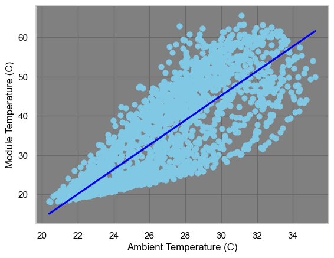

```python
fig, axes = plt.subplots()
sns.regplot(data = plant1, x = 'AMBIENT_TEMPERATURE', y = 'MODULE_TEMPERATURE', scatter_kws={'alpha':0.15, 'color' : 'skyblue'}, line_kws={'color': 'blue'})
axes.set_xlabel('Ambient Temperature (C)')
axes.set_ylabel('Module Temperature (C)');
r, p = scipy.stats.pearsonr(plant1['AMBIENT_TEMPERATURE'], plant1['MODULE_TEMPERATURE'])
print('r coefficient: ', r)
```

### DC to AC power conversion efficiency by output power

Since DC is converted to AC Power, some of it may not be fully converted. Here, we see the efficiency (proportion of AC power to DC power) of the conversion per AC output power.

```python
###Remove 0's from DC and AC
plant1_ACDC = plant1.copy()
plant1_ACDC = plant1_ACDC[plant1_ACDC['DC_POWER'] > 0]
plant1_ACDC = plant1_ACDC[plant1_ACDC['AC_POWER'] > 0]

#Assign is to make a new column
#Technically plant1_ACDC['EFFICIENCY'] = plant1['AC_POWER'] / plant1['DC_POWER'] works as well
#but there's a copy warning for it
plant1_ACDC = plant1_ACDC.assign(EFFICIENCY = plant1['AC_POWER'] / plant1['DC_POWER'])
plant1_ACDC.sample(10).style.background_gradient(cmap='YlGnBu')
```

|  | DATE_TIME | PLANT_ID_x | SOURCE_KEY_x | DC_POWER | AC_POWER | DAILY_YIELD | TOTAL_YIELD | PLANT_ID_y | SOURCE_KEY_y | AMBIENT_TEMPERATURE | MODULE_TEMPERATURE | IRRADIATION | DATE | TIME | HOURS | MINUTES | TOTAL MINUTES PASS | MONTH | DAY | DATE_STRING | EFFICIENCY |
| --- | --- | --- | --- | --- | --- | --- | --- | --- | --- | --- | --- | --- | --- | --- | --- | --- | --- | --- | --- | --- | --- |
| 26185 | 2020-05-28 08:30:00 | 4135001 | ih0vzX44oOqAx2f | 661.650000 | 648.100000 | 693.166667 | 6279559.167000 | 4135001 | HmiyD2TTLFNqkNe | 26.521838 | 40.798677 | 0.507256 | 2020-05-28 | 08:30:00 | 8 | 30 | 510 | 5 | 28 | 2020-05-28 | 0.979521 |
| 41047 | 2020-06-04 18:30:00 | 4135001 | uHbuxQJl8lW7ozc | 5.028571 | 4.842857 | 8279.714286 | 7194534.714000 | 4135001 | HmiyD2TTLFNqkNe | 25.491422 | 23.901589 | 0.004883 | 2020-06-04 | 18:30:00 | 18 | 30 | 1110 | 6 | 4 | 2020-06-04 | 0.963068 |
| 61515 | 2020-06-14 13:00:00 | 4135001 | 1IF53ai7Xc0U56Y | 897.900000 | 878.342857 | 4279.857143 | 6411160.857000 | 4135001 | HmiyD2TTLFNqkNe | 25.379936 | 34.780682 | 0.576180 | 2020-06-14 | 13:00:00 | 13 | 0 | 780 | 6 | 14 | 2020-06-14 | 0.978219 |
| 50363 | 2020-06-09 06:15:00 | 4135001 | 7JYdWkrLSPkdwr4 | 49.587500 | 47.975000 | 8.625000 | 7786801.625000 | 4135001 | HmiyD2TTLFNqkNe | 21.440216 | 19.855200 | 0.035888 | 2020-06-09 | 06:15:00 | 6 | 15 | 375 | 6 | 9 | 2020-06-09 | 0.967482 |
| 33946 | 2020-06-01 09:15:00 | 4135001 | zBIq5rxdHJRwDNY | 591.737500 | 579.950000 | 1252.625000 | 6464491.625000 | 4135001 | HmiyD2TTLFNqkNe | 26.586558 | 42.300411 | 0.420279 | 2020-06-01 | 09:15:00 | 9 | 15 | 555 | 6 | 1 | 2020-06-01 | 0.980080 |
| 10762 | 2020-05-20 07:30:00 | 4135001 | 1BY6WEcLGh8j5v7 | 326.971429 | 321.285714 | 185.571429 | 6290282.571000 | 4135001 | HmiyD2TTLFNqkNe | 23.434548 | 26.331181 | 0.264012 | 2020-05-20 | 07:30:00 | 7 | 30 | 450 | 5 | 20 | 2020-05-20 | 0.982611 |
| 933 | 2020-05-15 10:45:00 | 4135001 | YxYtjZvoooNbGkE | 508.114286 | 498.271429 | 1866.428571 | 7181832.429000 | 4135001 | HmiyD2TTLFNqkNe | 28.854708 | 44.048326 | 0.361962 | 2020-05-15 | 10:45:00 | 10 | 45 | 645 | 5 | 15 | 2020-05-15 | 0.980629 |
| 40461 | 2020-06-04 12:00:00 | 4135001 | 7JYdWkrLSPkdwr4 | 1069.450000 | 1043.812500 | 3545.625000 | 7752167.625000 | 4135001 | HmiyD2TTLFNqkNe | 29.428778 | 54.029262 | 0.849540 | 2020-06-04 | 12:00:00 | 12 | 0 | 720 | 6 | 4 | 2020-06-04 | 0.976027 |
| 14040 | 2020-05-22 10:00:00 | 4135001 | wCURE6d3bPkepu2 | 666.314286 | 652.214286 | 1414.714286 | 6833469.714000 | 4135001 | HmiyD2TTLFNqkNe | 27.585663 | 42.067015 | 0.542687 | 2020-05-22 | 10:00:00 | 10 | 0 | 600 | 5 | 22 | 2020-05-22 | 0.978839 |
| 53313 | 2020-06-10 15:45:00 | 4135001 | VHMLBKoKgIrUVDU | 381.314286 | 374.742857 | 5840.428571 | 7408656.429000 | 4135001 | HmiyD2TTLFNqkNe | 25.179918 | 32.456162 | 0.247411 | 2020-06-10 | 15:45:00 | 15 | 45 | 945 | 6 | 10 | 2020-06-10 | 0.982766 |

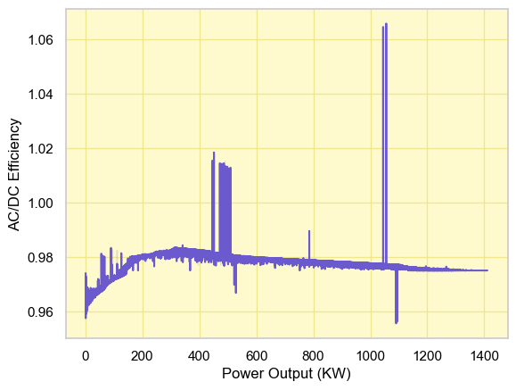

```python
#Disable warnings
with warnings.catch_warnings():
    warnings.simplefilter('ignore')
    #Temporarily change style for this graph
    custom_style = {'axes.labelcolor': 'black',
                    'xtick.color': 'black',
                    'ytick.color': 'black',
                   'axes.facecolor': 'lemonchiffon',
                   'grid.color': 'khaki'}
    #Completely replace the "whitegrid" seaborn style with my new custom style
    #My custom style is my attempt to recreate the "theme_dark" style from ggplot2 in R
    sns.set_style("whitegrid", rc=custom_style)
    fig, axes = plt.subplots()
    sns.lineplot(data = plant1_ACDC, x = 'AC_POWER', y = 'EFFICIENCY', color = 'slateblue')
    axes.set_xlabel('Power Output (KW)')
    axes.set_ylabel('AC/DC Efficiency');

#Reset style
custom_style = {'axes.labelcolor': 'black',
                'xtick.color': 'black',
                'ytick.color': 'black',
               'axes.facecolor': 'gray',
               'grid.color': 'dimgray'}
#Completely replace the "whitegrid" seaborn style with my new custom style
#My custom style is my attempt to recreate the "theme_dark" style from ggplot2 in R
sns.set_style("whitegrid", rc=custom_style)
```

```python
plant1_ACDC[plant1_ACDC['AC_POWER'] > plant1_ACDC['DC_POWER']]
```

|  | DATE_TIME | PLANT_ID_x | SOURCE_KEY_x | DC_POWER | AC_POWER | DAILY_YIELD | TOTAL_YIELD | PLANT_ID_y | SOURCE_KEY_y | AMBIENT_TEMPERATURE | ... | IRRADIATION | DATE | TIME | HOURS | MINUTES | TOTAL MINUTES PASS | MONTH | DAY | DATE_STRING | EFFICIENCY |
| --- | --- | --- | --- | --- | --- | --- | --- | --- | --- | --- | --- | --- | --- | --- | --- | --- | --- | --- | --- | --- | --- |
| 14290 | 2020-05-22 13:00:00 | 4135001 | McdE0feGgRqW7Ca | 990.457143 | 1055.750000 | 4057.000000 | 7213112.000 | 4135001 | HmiyD2TTLFNqkNe | 31.318955 | ... | 0.814844 | 2020-05-22 | 13:00:00 | 13 | 0 | 780 | 5 | 22 | 2020-05-22 | 1.065922 |
| 14302 | 2020-05-22 13:00:00 | 4135001 | sjndEbLyjtCKgGv | 981.428571 | 1044.900000 | 4280.000000 | 7070166.000 | 4135001 | HmiyD2TTLFNqkNe | 31.318955 | ... | 0.814844 | 2020-05-22 | 13:00:00 | 13 | 0 | 780 | 5 | 22 | 2020-05-22 | 1.064672 |
| 61118 | 2020-06-14 08:30:00 | 4135001 | 1BY6WEcLGh8j5v7 | 443.100000 | 451.285714 | 567.142857 | 6464230.143 | 4135001 | HmiyD2TTLFNqkNe | 23.901831 | ... | 0.335355 | 2020-06-14 | 08:30:00 | 8 | 30 | 510 | 6 | 14 | 2020-06-14 | 1.018474 |
| 61119 | 2020-06-14 08:30:00 | 4135001 | 1IF53ai7Xc0U56Y | 495.575000 | 501.742857 | 632.857143 | 6407513.857 | 4135001 | HmiyD2TTLFNqkNe | 23.901831 | ... | 0.335355 | 2020-06-14 | 08:30:00 | 8 | 30 | 510 | 6 | 14 | 2020-06-14 | 1.012446 |
| 61121 | 2020-06-14 08:30:00 | 4135001 | 7JYdWkrLSPkdwr4 | 479.250000 | 484.928571 | 615.714286 | 7821467.714 | 4135001 | HmiyD2TTLFNqkNe | 23.901831 | ... | 0.335355 | 2020-06-14 | 08:30:00 | 8 | 30 | 510 | 6 | 14 | 2020-06-14 | 1.011849 |
| 61122 | 2020-06-14 08:30:00 | 4135001 | McdE0feGgRqW7Ca | 485.625000 | 492.114286 | 633.571429 | 7382556.571 | 4135001 | HmiyD2TTLFNqkNe | 23.901831 | ... | 0.335355 | 2020-06-14 | 08:30:00 | 8 | 30 | 510 | 6 | 14 | 2020-06-14 | 1.013363 |
| 61123 | 2020-06-14 08:30:00 | 4135001 | VHMLBKoKgIrUVDU | 491.750000 | 498.242857 | 627.857143 | 7430193.857 | 4135001 | HmiyD2TTLFNqkNe | 23.901831 | ... | 0.335355 | 2020-06-14 | 08:30:00 | 8 | 30 | 510 | 6 | 14 | 2020-06-14 | 1.013204 |
| 61126 | 2020-06-14 08:30:00 | 4135001 | ZnxXDlPa8U1GXgE | 479.162500 | 486.114286 | 612.714286 | 6744955.714 | 4135001 | HmiyD2TTLFNqkNe | 23.901831 | ... | 0.335355 | 2020-06-14 | 08:30:00 | 8 | 30 | 510 | 6 | 14 | 2020-06-14 | 1.014508 |
| 61128 | 2020-06-14 08:30:00 | 4135001 | adLQvlD726eNBSB | 502.575000 | 509.042857 | 645.142857 | 6498141.143 | 4135001 | HmiyD2TTLFNqkNe | 23.901831 | ... | 0.335355 | 2020-06-14 | 08:30:00 | 8 | 30 | 510 | 6 | 14 | 2020-06-14 | 1.012869 |
| 61129 | 2020-06-14 08:30:00 | 4135001 | bvBOhCH3iADSZry | 439.037500 | 445.828571 | 560.142857 | 6518202.143 | 4135001 | HmiyD2TTLFNqkNe | 23.901831 | ... | 0.335355 | 2020-06-14 | 08:30:00 | 8 | 30 | 510 | 6 | 14 | 2020-06-14 | 1.015468 |
| 61130 | 2020-06-14 08:30:00 | 4135001 | iCRJl6heRkivqQ3 | 482.587500 | 489.000000 | 616.714286 | 7400471.714 | 4135001 | HmiyD2TTLFNqkNe | 23.901831 | ... | 0.335355 | 2020-06-14 | 08:30:00 | 8 | 30 | 510 | 6 | 14 | 2020-06-14 | 1.013288 |
| 61131 | 2020-06-14 08:30:00 | 4135001 | ih0vzX44oOqAx2f | 465.337500 | 472.085714 | 601.428571 | 6401119.429 | 4135001 | HmiyD2TTLFNqkNe | 23.901831 | ... | 0.335355 | 2020-06-14 | 08:30:00 | 8 | 30 | 510 | 6 | 14 | 2020-06-14 | 1.014502 |
| 61133 | 2020-06-14 08:30:00 | 4135001 | rGa61gmuvPhdLxV | 492.300000 | 499.114286 | 610.285714 | 7331280.286 | 4135001 | HmiyD2TTLFNqkNe | 23.901831 | ... | 0.335355 | 2020-06-14 | 08:30:00 | 8 | 30 | 510 | 6 | 14 | 2020-06-14 | 1.013842 |
| 61134 | 2020-06-14 08:30:00 | 4135001 | sjndEbLyjtCKgGv | 479.512500 | 485.400000 | 619.142857 | 7236123.143 | 4135001 | HmiyD2TTLFNqkNe | 23.901831 | ... | 0.335355 | 2020-06-14 | 08:30:00 | 8 | 30 | 510 | 6 | 14 | 2020-06-14 | 1.012278 |
| 61136 | 2020-06-14 08:30:00 | 4135001 | wCURE6d3bPkepu2 | 474.050000 | 480.485714 | 615.714286 | 7002984.714 | 4135001 | HmiyD2TTLFNqkNe | 23.901831 | ... | 0.335355 | 2020-06-14 | 08:30:00 | 8 | 30 | 510 | 6 | 14 | 2020-06-14 | 1.013576 |
| 61137 | 2020-06-14 08:30:00 | 4135001 | z9Y9gH1T5YWrNuG | 472.437500 | 479.185714 | 622.285714 | 7225852.286 | 4135001 | HmiyD2TTLFNqkNe | 23.901831 | ... | 0.335355 | 2020-06-14 | 08:30:00 | 8 | 30 | 510 | 6 | 14 | 2020-06-14 | 1.014284 |
| 61138 | 2020-06-14 08:30:00 | 4135001 | zBIq5rxdHJRwDNY | 481.825000 | 487.728571 | 607.857143 | 6558429.857 | 4135001 | HmiyD2TTLFNqkNe | 23.901831 | ... | 0.335355 | 2020-06-14 | 08:30:00 | 8 | 30 | 510 | 6 | 14 | 2020-06-14 | 1.012253 |
| 61139 | 2020-06-14 08:30:00 | 4135001 | zVJPv84UY57bAof | 480.287500 | 487.671429 | 618.571429 | 7337578.571 | 4135001 | HmiyD2TTLFNqkNe | 23.901831 | ... | 0.335355 | 2020-06-14 | 08:30:00 | 8 | 30 | 510 | 6 | 14 | 2020-06-14 | 1.015374 |

18 rows × 21 columns

### Irradiation and AC Power

Irradiation helps indicate the amount of radiation that power plant receives. This includes solar radiation, so we wish to plot its relationship with AC Power generation.

```
r coefficient:  0.9893400640396757
```

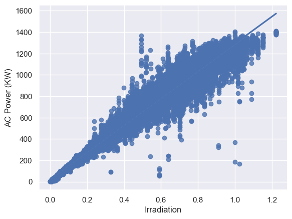

```python
sns.set_theme(style="darkgrid")
fig, axes = plt.subplots()
sns.regplot(data = plant1_ACDC, x = 'IRRADIATION', y = 'AC_POWER')
axes.set_xlabel('Irradiation')
axes.set_ylabel('AC Power (KW)');
r, p = scipy.stats.pearsonr(plant1['IRRADIATION'], plant1['AC_POWER'])
print('r coefficient: ', r)
```

We see that irradiation has a strongly positive correlation with AC power production.

## Machine Learning Prediction

We wish to predict the amount of power generated by our plant on a given day. Our prediction variable will be AC power. We have a few caveats:

1. We can **not** use DC power in our features because DC power and AC power have about a $y=x$ relationship because DC power is converted to AC power. We are assuming that we have not gathered data for DC power yet.
2. We can not use Total and Daily yield because they are based on how much DC power was generated by that time of day/ by that inverter cumulative.
3. This is data taken between May and June. Since weather plays a big role in soalr energy production, the results here are not indicative of Fall, Winter, and early Spring weather. Thus, our model may not be able to predict energy output from those dates as accurately.
4. Since this is a time-series, we will compare a randomized train-validation-test split, and then compare with chronological splits based on time for train, validation, and test sets. This will assess the degree of importance of time as a feature.

### Linear Regression

```python
#We do one-hot encoding for the hour of the day to make it  numerical (1 if between 6 AM to 7 PM
#(19:00:00) excluding 7 pm, 0 else)
plant1['IS_ACTIVE'] = plant1['HOURS'].map({'0': 0, '1':0, '2':0, '3':0, '4':0, '5':0, '6':1, '7': 1, '8':1, '9':1, '10':1, '11':1,
                                '12':1, '13':1, '14':1, '15':1, '16':1, '17':1, '18':1, '19':0, '20':0, '21':0, '22':0, '23':0})


regressionDataFrame = plant1.copy()


# For regression, since there are thousands of inverters, I instead take their median power output at a given time.
# Hence, I group by the date time to have only one AC output per date and time.
regressionDataFrame = regressionDataFrame.groupby(['DATE_TIME']).agg({'AC_POWER' : 'median', 'AMBIENT_TEMPERATURE' : 'mean',
                                                                     'MODULE_TEMPERATURE': 'mean', 'IRRADIATION' : 'mean',
                                                                     'IS_ACTIVE' : 'mean',
                                                                      #TIME is a string, so we can't use mean, median, etc.
                                                                      #I go for 'mode' instead (most common occurence), which doesn't have a specific method,
                                                                      #so I create it as a lambda function below
                                                                      'TIME' : lambda x: x.mode().iloc[0]})

regression_features = ['MODULE_TEMPERATURE', 'AMBIENT_TEMPERATURE', 'IRRADIATION', 'IS_ACTIVE']
X = regressionDataFrame[regression_features]
y = regressionDataFrame['AC_POWER']
```

```python
## Train test split
train_valid_regression_X, test_regression_X, train_valid_regression_y, test_regression_y = train_test_split(X,y, test_size = .2)
train_regression_X, valid_regression_X, train_regression_y, valid_regression_y = train_test_split(train_valid_regression_X, train_valid_regression_y, test_size = .125)

##Preprocessing data
#sklearn.preprocessing.StandardScaler().fit both fits the data AND standardizes the data to get mean 0 and std 1. But assumes
#data is gaussian

#sklearn.preprocessing.MinMaxScaler().fit on the other hand bfings values to be within [0,1]
scaler = sklearn.preprocessing.MinMaxScaler().fit(train_regression_X)

#Apply to both train and validation x set

train_regression_X = scaler.transform(train_regression_X )

#As stated above, we use the scaler that was fitted/standardized on train_sales to transform the validation and test data
valid_regression_X = scaler.transform(valid_regression_X)


test_regression_X = scaler.transform(test_regression_X)
```

```python
train_regression_X
```

```
array([[0.66704313, 0.86774849, 0.54729432, 1.        ],
       [0.08864267, 0.21806268, 0.        , 0.        ],
       [0.39040448, 0.44962278, 0.34218562, 1.        ],
       ...,
       [0.06584563, 0.1930788 , 0.        , 0.        ],
       [0.38172438, 0.32091531, 0.32128173, 1.        ],
       [0.07000083, 0.22465558, 0.        , 0.        ]])
```

```python
valid_regression_y
```

```
DATE_TIME
2020-05-17 07:30:00    277.823214
2020-05-30 09:45:00    456.028571
2020-06-01 20:15:00      0.000000
2020-05-24 04:45:00      0.000000
2020-06-15 12:30:00    558.860714
                          ...
2020-06-01 05:45:00      0.000000
2020-05-27 22:45:00      0.000000
2020-06-03 04:45:00      0.000000
2020-06-04 01:45:00      0.000000
2020-05-15 16:00:00    490.693750
Name: AC_POWER, Length: 316, dtype: float64
```

### Baseline Linear Regression (Least Squares)

We will keep track of the RMSE's of each model.

```python
RMSE_list = []
```

```python
from sklearn.linear_model import LinearRegression

basic_model = LinearRegression().fit(train_regression_X, train_regression_y)

#Get the rmse; start by importing the mean_squared_error
from sklearn.metrics import mean_squared_error


#See how well model predicts train y
train_predicted_unregularized_y = basic_model.predict(train_regression_X)

#Compute train RMSE
train_rmse_unregularized = np.sqrt(mean_squared_error(train_regression_y, train_predicted_unregularized_y))

#Get validation predicted price
valid_predicted_unregularized_y = basic_model.predict(valid_regression_X)

#Compute validation RMSE
valid_rmse_unregularized = np.sqrt(mean_squared_error(valid_regression_y, valid_predicted_unregularized_y))
RMSE_list.append(('Unregularized train RMSE: ', train_rmse_unregularized))
RMSE_list.append(('Unregularized validation RMSE: ', valid_rmse_unregularized))
```

```python
pd.DataFrame({'Actual': valid_regression_y, 'Predicted': valid_predicted_unregularized_y, 'Error': np.abs(valid_regression_y - valid_predicted_unregularized_y)}).sample(100).style.background_gradient(cmap='Grays')
```

| DATE_TIME | Actual | Predicted | Error |
| --- | --- | --- | --- |
| 2020-06-01 05:15:00 | 0.000000 | -0.573916 | 0.573916 |
| 2020-06-03 23:15:00 | 0.000000 | 0.550656 | 0.550656 |
| 2020-05-17 23:45:00 | 0.000000 | 1.252212 | 1.252212 |
| 2020-06-10 03:30:00 | 0.000000 | -0.901673 | 0.901673 |
| 2020-06-05 14:45:00 | 1063.443750 | 1039.226464 | 24.217286 |
| 2020-06-01 20:45:00 | 0.000000 | -1.109571 | 1.109571 |
| 2020-06-02 03:45:00 | 0.000000 | -0.133322 | 0.133322 |
| 2020-06-06 01:15:00 | 0.000000 | -1.528270 | 1.528270 |
| 2020-06-09 23:30:00 | 0.000000 | -0.735555 | 0.735555 |
| 2020-06-11 04:15:00 | 0.000000 | -0.101923 | 0.101923 |
| 2020-06-02 15:15:00 | 530.800000 | 486.526898 | 44.273102 |
| 2020-06-17 18:15:00 | 32.756250 | 52.652893 | 19.896643 |
| 2020-06-09 05:45:00 | 0.000000 | -0.026660 | 0.026660 |
| 2020-05-27 10:15:00 | 589.875893 | 612.685268 | 22.809375 |
| 2020-06-09 04:45:00 | 0.000000 | -0.201822 | 0.201822 |
| 2020-06-06 14:45:00 | 237.517857 | 212.833651 | 24.684206 |
| 2020-06-16 22:45:00 | 0.000000 | -0.317768 | 0.317768 |
| 2020-05-29 13:00:00 | 1231.085714 | 1273.961249 | 42.875535 |
| 2020-06-01 01:45:00 | 0.000000 | -0.803505 | 0.803505 |
| 2020-06-04 02:45:00 | 0.000000 | -1.247537 | 1.247537 |
| 2020-05-22 13:00:00 | 1048.728572 | 1063.743235 | 15.014663 |
| 2020-06-02 06:30:00 | 46.850000 | 66.247961 | 19.397961 |
| 2020-06-09 07:15:00 | 256.150000 | 318.766910 | 62.616910 |
| 2020-05-29 06:30:00 | 96.064286 | 104.215191 | 8.150906 |
| 2020-06-02 22:00:00 | 0.000000 | -1.047275 | 1.047275 |
| 2020-05-25 09:00:00 | 809.614286 | 813.158532 | 3.544246 |
| 2020-05-17 03:30:00 | 0.000000 | -0.498253 | 0.498253 |
| 2020-06-15 20:00:00 | 0.000000 | 1.552411 | 1.552411 |
| 2020-05-27 02:00:00 | 0.000000 | 0.067548 | 0.067548 |
| 2020-05-21 09:00:00 | 808.000000 | 829.650244 | 21.650244 |

[output cut: 70 more lines]

```python
train_rmse_unregularized
```

```
32.37632080632219
```

```python
valid_rmse_unregularized
```

```
30.96758602444839
```

### Ridge Regression

```python
#Lambda Parameter. We try out each one
l2_lambdas = np.logspace(-5, 5, 11, base = 10)


#Import Ridge Regression
from sklearn.linear_model import Ridge

#Start with empty dataset that consists of each model's hyper parameter, rmse, etc.
#After the for loop, we make a pondas dataframe out of it
data = []
for each_lambda in l2_lambdas:
    ridge_model = Ridge(alpha=each_lambda)
     #Train the ridge model
    ridge_model.fit(train_regression_X, train_regression_y)

    #Training predicted y
    ridge_predicted_train_y = ridge_model.predict(train_regression_X)

    #For the validation rmse, we need to predict the validation prices:
    ridge_predicted_valid_y = ridge_model.predict(valid_regression_X)
    data.append({
        'l2_penalty': each_lambda,
        'model': ridge_model,
        'train_rmse': np.sqrt(mean_squared_error(train_regression_y, ridge_predicted_train_y)),
        'validation_rmse': np.sqrt(mean_squared_error(valid_regression_y, ridge_predicted_valid_y))
    })

ridge_data = pd.DataFrame(data)
```

```python
ridge_data
```

|  | l2_penalty | model | train_rmse | validation_rmse |
| --- | --- | --- | --- | --- |
| 0 | 0.00001 | Ridge(alpha=1e-05) | 32.376321 | 30.967595 |
| 1 | 0.00010 | Ridge(alpha=0.0001) | 32.376321 | 30.967674 |
| 2 | 0.00100 | Ridge(alpha=0.001) | 32.376323 | 30.968467 |
| 3 | 0.01000 | Ridge(alpha=0.01) | 32.376513 | 30.976504 |
| 4 | 0.10000 | Ridge(alpha=0.1) | 32.394078 | 31.066182 |
| 5 | 1.00000 | Ridge() | 33.314811 | 32.326422 |
| 6 | 10.00000 | Ridge(alpha=10.0) | 45.116818 | 42.860375 |
| 7 | 100.00000 | Ridge(alpha=100.0) | 120.578791 | 108.106375 |
| 8 | 1000.00000 | Ridge(alpha=1000.0) | 265.652049 | 250.465229 |
| 9 | 10000.00000 | Ridge(alpha=10000.0) | 374.199237 | 363.203299 |
| 10 | 100000.00000 | Ridge(alpha=100000.0) | 394.172515 | 383.966515 |

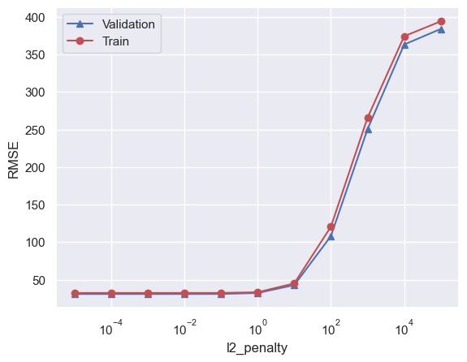

```python
# Plot the validation RMSE as a blue line with dots
plt.plot(ridge_data['l2_penalty'], ridge_data['validation_rmse'],
         'b-^', label='Validation')
# Plot the train RMSE as a red line dots
plt.plot(ridge_data['l2_penalty'], ridge_data['train_rmse'],
         'r-o', label='Train')

# Make the x-axis log scale for readability
plt.xscale('log')

# Label the axes and make a legend
plt.xlabel('l2_penalty')
plt.ylabel('RMSE')
plt.legend();
```

```python
#The best lambda is the one that minimizes validation error. Hence, we search for its index:
best_lambda_index = ridge_data['validation_rmse'].idxmin()
#Use the index to find the row corresponding to the best lambda using .loc
best_row = ridge_data.loc[best_lambda_index]

#Now get the lambda from the row we got that contains it:
best_l2 = best_row['l2_penalty']



#Time to calculate the test remse for the ridge model we picked.
#First get the model corresponding to our row:
best_model = best_row['model']


#Predict the prices from it
best_predict_train_y = best_model.predict(train_regression_X)
best_predict_y = best_model.predict(valid_regression_X)

#Now calculate the rmse
train_rmse_ridge = np.sqrt(mean_squared_error(train_regression_y, best_predict_train_y))
valid_rmse_ridge = np.sqrt(mean_squared_error(valid_regression_y, best_predict_y))

RMSE_list.append(('Ridge Regression Train RMSE: ', train_rmse_ridge))
RMSE_list.append(('Ridge Regression Validation RMSE: ', valid_rmse_ridge))

#The helper function prints the coefficients
def print_coefficients(model, features):
    """
    This function takes in a model column and a features column.
    And prints the coefficient along with its feature name.
    """
    feats = list(zip(features, model.coef_))
    print(*feats, sep = "\n")

#Let's see our coefficients
print_coefficients(best_model, regression_features)

# #Let's start counting the number of coefficients that are 0
# num_zero_coeffs_ridge = 0

# for i in best_model.coef_: #This is an array of all the coefficients of our model; it's from the helper function.
#     if np.abs(i) <.0001:
#         num_zero_coeffs_ridge +=1

# #Note: in real life, instead of i==0, I would do something like |i| < .00001 because of potential truncation error.
```

```
('MODULE_TEMPERATURE', 76.49341147648313)
('AMBIENT_TEMPERATURE', -19.24188808295233)
('IRRADIATION', 1412.1037842926335)
('IS_ACTIVE', 20.647344273464867)
```

```python
pd.DataFrame({'Actual': valid_regression_y, 'Predicted': best_predict_y, 'Error': np.abs(valid_regression_y - best_predict_y)}).sample(100).style.background_gradient(cmap='OrRd')
```

| DATE_TIME | Actual | Predicted | Error |
| --- | --- | --- | --- |
| 2020-06-15 05:00:00 | 0.000000 | 0.094928 | 0.094928 |
| 2020-05-22 08:45:00 | 378.411607 | 363.307678 | 15.103929 |
| 2020-05-23 16:15:00 | 566.278571 | 596.011897 | 29.733325 |
| 2020-05-26 05:15:00 | 0.000000 | -1.660329 | 1.660329 |
| 2020-05-25 12:30:00 | 1233.412500 | 1254.801486 | 21.388986 |
| 2020-05-20 05:30:00 | 0.000000 | -2.426442 | 2.426442 |
| 2020-06-10 06:00:00 | 9.125893 | 30.318942 | 21.193049 |
| 2020-05-19 20:00:00 | 0.000000 | -1.083839 | 1.083839 |
| 2020-05-22 17:45:00 | 49.942857 | 71.072602 | 21.129745 |
| 2020-05-27 22:30:00 | 0.000000 | -0.460617 | 0.460617 |
| 2020-05-18 05:30:00 | 0.000000 | 0.379920 | 0.379920 |
| 2020-05-27 22:45:00 | 0.000000 | 0.287481 | 0.287481 |
| 2020-05-24 07:45:00 | 395.392857 | 433.471747 | 38.078890 |
| 2020-06-06 19:15:00 | 0.000000 | 1.095106 | 1.095106 |
| 2020-05-17 18:30:00 | 0.000000 | 23.774377 | 23.774377 |
| 2020-05-20 03:45:00 | 0.000000 | -1.631999 | 1.631999 |
| 2020-05-17 09:30:00 | 816.512500 | 823.955311 | 7.442811 |
| 2020-05-15 16:00:00 | 490.693750 | 480.975108 | 9.718642 |
| 2020-05-17 22:45:00 | 0.000000 | 1.320525 | 1.320525 |
| 2020-06-16 10:45:00 | 931.830357 | 883.242519 | 48.587838 |
| 2020-06-17 05:30:00 | 0.000000 | 1.682535 | 1.682535 |
| 2020-06-10 00:30:00 | 0.000000 | -0.217790 | 0.217790 |
| 2020-06-08 04:30:00 | 0.000000 | 0.462020 | 0.462020 |
| 2020-06-09 04:00:00 | 0.000000 | -0.595542 | 0.595542 |
| 2020-05-29 12:00:00 | 1156.407143 | 1150.922592 | 5.484551 |
| 2020-05-18 16:30:00 | 364.739286 | 351.835644 | 12.903641 |
| 2020-06-02 15:15:00 | 530.800000 | 486.526906 | 44.273094 |
| 2020-05-28 08:00:00 | 484.601786 | 522.416360 | 37.814574 |
| 2020-05-25 13:45:00 | 1147.829465 | 1147.374199 | 0.455266 |
| 2020-06-06 14:00:00 | 718.925000 | 610.577428 | 108.347572 |

[output cut: 70 more lines]

### Lasso Regression

```python
#Lambda Parameter. We try out each one
l1_lambdas = np.logspace(-5, 5, 11, base = 10)


#Import Lasso Regression
from sklearn.linear_model import Lasso
#Start with empty dataset that consists of each model's hyper parameter, rmse, etc.
#After the for loop, we make a pondas dataframe out of it
data = []
for each_lambda in l1_lambdas:
    lasso_model = Lasso(alpha=each_lambda)
     #Train the lasso model
    lasso_model.fit(train_regression_X, train_regression_y)

    #Training predicted y
    lasso_predicted_train_y = lasso_model.predict(train_regression_X)

    #For the validation rmse, we need to predict the validation prices:
    lasso_predicted_valid_y = lasso_model.predict(valid_regression_X)
    data.append({
        'l1_penalty': each_lambda,
        'model': lasso_model,
        'train_rmse': np.sqrt(mean_squared_error(train_regression_y, lasso_predicted_train_y)),
        'validation_rmse': np.sqrt(mean_squared_error(valid_regression_y, lasso_predicted_valid_y))
    })

lasso_data = pd.DataFrame(data)
```

```python
lasso_data
```

|  | l1_penalty | model | train_rmse | validation_rmse |
| --- | --- | --- | --- | --- |
| 0 | 0.00001 | Lasso(alpha=1e-05) | 32.376321 | 30.967583 |
| 1 | 0.00010 | Lasso(alpha=0.0001) | 32.376321 | 30.967554 |
| 2 | 0.00100 | Lasso(alpha=0.001) | 32.376324 | 30.967247 |
| 3 | 0.01000 | Lasso(alpha=0.01) | 32.376674 | 30.963753 |
| 4 | 0.10000 | Lasso(alpha=0.1) | 32.421351 | 30.924613 |
| 5 | 1.00000 | Lasso() | 32.664127 | 31.162601 |
| 6 | 10.00000 | Lasso(alpha=10.0) | 50.633202 | 48.644821 |
| 7 | 100.00000 | Lasso(alpha=100.0) | 347.952517 | 333.519381 |
| 8 | 1000.00000 | Lasso(alpha=1000.0) | 396.580386 | 386.468911 |
| 9 | 10000.00000 | Lasso(alpha=10000.0) | 396.580386 | 386.468911 |
| 10 | 100000.00000 | Lasso(alpha=100000.0) | 396.580386 | 386.468911 |

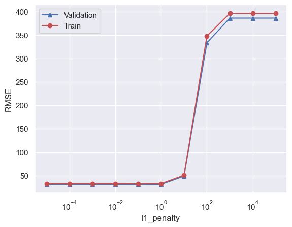

```python
# Plot the validation RMSE as a blue line with dots
plt.plot(lasso_data['l1_penalty'], lasso_data['validation_rmse'],
         'b-^', label='Validation')
# Plot the train RMSE as a red line dots
plt.plot(lasso_data['l1_penalty'], lasso_data['train_rmse'],
         'r-o', label='Train')

# Make the x-axis log scale for readability
plt.xscale('log')

# Label the axes and make a legend
plt.xlabel('l1_penalty')
plt.ylabel('RMSE')
plt.legend();
```

```python
#The best lambda is the one that minimizes validation error. Hence, we search for its index:
best_lambda_index_lasso = lasso_data['validation_rmse'].idxmin()
#Use the index to find the row corresponding to the best lambda using .loc
best_row_lasso = lasso_data.loc[best_lambda_index_lasso]

#Now get the lambda from the row we got that contains it:
best_l1 = best_row_lasso['l1_penalty']



#Time to calculate the test remse for the ridge model we picked.
#First get the model corresponding to our row:
best_model_lasso = best_row_lasso['model']

#Predict the prices from it
best_predict_train_y_lasso = best_model_lasso.predict(train_regression_X)
best_predict_y_lasso = best_model_lasso.predict(valid_regression_X)

#Now calculate the rmse
train_rmse_lasso = np.sqrt(mean_squared_error(train_regression_y, best_predict_train_y_lasso))
valid_rmse_lasso = np.sqrt(mean_squared_error(valid_regression_y, best_predict_y_lasso))

RMSE_list.append(('LASSO Regression Train RMSE: ', train_rmse_lasso))
RMSE_list.append(('LASSO Regression  Validation RMSE: ', valid_rmse_lasso))

#Let's see our coefficients
print_coefficients(best_model_lasso, regression_features)

# #Let's start counting the number of coefficients that are 0
# num_zero_coeffs_ridge = 0

# for i in best_model.coef_: #This is an array of all the coefficients of our model; it's from the helper function.
#     if np.abs(i) <.0001:
#         num_zero_coeffs_ridge +=1

# #Note: in real life, instead of i==0, I would do something like |i| < .00001 because of potential truncation error.
```

```
('MODULE_TEMPERATURE', 41.72405833253862)
('AMBIENT_TEMPERATURE', -0.0)
('IRRADIATION', 1432.1715938062296)
('IS_ACTIVE', 20.427273495970155)
```

```python
pd.DataFrame({'Actual': valid_regression_y, 'Predicted': best_predict_y_lasso, 'Error': np.abs(valid_regression_y - best_predict_y_lasso)}).sample(100).style.background_gradient(cmap='RdPu')
```

| DATE_TIME | Actual | Predicted | Error |
| --- | --- | --- | --- |
| 2020-06-07 15:30:00 | 770.250000 | 734.014740 | 36.235260 |
| 2020-05-21 16:30:00 | 427.809821 | 409.629174 | 18.180648 |
| 2020-06-09 00:00:00 | 0.000000 | -1.410459 | 1.410459 |
| 2020-05-21 22:15:00 | 0.000000 | 0.485388 | 0.485388 |
| 2020-06-17 18:15:00 | 32.756250 | 52.189700 | 19.433450 |
| 2020-05-29 21:30:00 | 0.000000 | 2.747843 | 2.747843 |
| 2020-06-03 23:15:00 | 0.000000 | 0.578760 | 0.578760 |
| 2020-06-10 04:30:00 | 0.000000 | -1.142723 | 1.142723 |
| 2020-05-30 08:30:00 | 350.406250 | 352.392387 | 1.986137 |
| 2020-05-20 03:45:00 | 0.000000 | -1.430901 | 1.430901 |
| 2020-06-05 09:45:00 | 555.831250 | 543.555213 | 12.276037 |
| 2020-06-16 03:15:00 | 0.000000 | 0.051349 | 0.051349 |
| 2020-05-23 23:00:00 | 0.000000 | 1.371183 | 1.371183 |
| 2020-05-19 15:15:00 | 594.482143 | 578.030415 | 16.451727 |
| 2020-06-12 19:15:00 | 0.000000 | 1.785977 | 1.785977 |
| 2020-05-26 09:00:00 | 801.172321 | 807.157983 | 5.985661 |
| 2020-06-01 05:45:00 | 0.000000 | -1.263289 | 1.263289 |
| 2020-06-09 19:00:00 | 0.000000 | 2.134103 | 2.134103 |
| 2020-06-09 10:15:00 | 998.275000 | 995.592480 | 2.682520 |
| 2020-05-28 05:00:00 | 0.000000 | -1.212964 | 1.212964 |
| 2020-05-24 15:45:00 | 292.362500 | 303.960661 | 11.598161 |
| 2020-06-06 06:15:00 | 39.992857 | 58.368772 | 18.375915 |
| 2020-05-25 03:15:00 | 0.000000 | 1.019466 | 1.019466 |
| 2020-05-17 23:45:00 | 0.000000 | -0.493173 | 0.493173 |
| 2020-06-03 04:45:00 | 0.000000 | 0.071635 | 0.071635 |
| 2020-06-06 10:45:00 | 841.336607 | 782.627992 | 58.708615 |
| 2020-05-24 10:00:00 | 681.851786 | 761.932865 | 80.081079 |
| 2020-06-06 21:30:00 | 0.000000 | -0.541342 | 0.541342 |
| 2020-06-02 02:15:00 | 0.000000 | -1.326759 | 1.326759 |
| 2020-06-16 22:45:00 | 0.000000 | -0.174559 | 0.174559 |

[output cut: 70 more lines]

We see that our unregularized regression model was about the same as our ridge/lasso regression. This is most likely due to the features being highly correlated amongst each other, which makes sense given our analysis above (Module temperature is strongly correlated with Ambient temperature, etc)

Thus, colinearity may potentially affect our model, so we must proceed with caution.

### Elastic-Net Regression (Hybrid of Ridge and Lasso)

```python
#L1 and L2 ratio.
l1_l2 = [.1, .5, .7, .9, .95, .99, 1]


#Import Lasso Regression
from sklearn.linear_model import ElasticNetCV
#Start with empty dataset that consists of each model's hyper parameter, rmse, etc.
#After the for loop, we make a pondas dataframe out of it
#Note that ElasticNetCV cross validates our l1 l2 ratio, hence the CV in the name.
data_elastic = []

elastic_model = ElasticNetCV(l1_ratio = l1_l2, tol = 1e-5)
elastic_model.fit(train_regression_X, train_regression_y)
elastic_predicted_train_y = elastic_model.predict(train_regression_X)
elastic_predicted_valid_y = elastic_model.predict(valid_regression_X)

train_rmse_elastic = np.sqrt(mean_squared_error(train_regression_y, elastic_predicted_train_y))
valid_rmse_elastic =  np.sqrt(mean_squared_error(valid_regression_y, elastic_predicted_valid_y))
data_elastic.append({
    'l1/l2 Ratio': elastic_model.l1_ratio,
        'model': elastic_model,
        'train_rmse': train_rmse_elastic ,
        'validation_rmse': valid_rmse_elastic
    }
)

RMSE_list.append(('Elastic Net Train RMSE: ', train_rmse_elastic) )
RMSE_list.append(('Elastic Net Validation RMSE: ', valid_rmse_elastic))

elastic_data = pd.DataFrame(data_elastic)
```

```python
elastic_data
```

|  | l1/l2 Ratio | model | train_rmse | validation_rmse |
| --- | --- | --- | --- | --- |
| 0 | [0.1, 0.5, 0.7, 0.9, 0.95, 0.99, 1] | ElasticNetCV(l1_ratio=[0.1, 0.5, 0.7, 0.9, 0.9... | 32.423749 | 30.920686 |

```python
pd.DataFrame({'Actual': valid_regression_y, 'Predicted': elastic_predicted_valid_y, 'Error': np.abs(valid_regression_y - elastic_predicted_valid_y)}).sample(100).style.background_gradient(cmap='Blues')
```

| DATE_TIME | Actual | Predicted | Error |
| --- | --- | --- | --- |
| 2020-05-17 05:30:00 | 0.000000 | 0.051067 | 0.051067 |
| 2020-06-05 05:15:00 | 0.000000 | -1.350608 | 1.350608 |
| 2020-05-21 15:30:00 | 740.425000 | 743.461077 | 3.036077 |
| 2020-05-19 15:15:00 | 594.482143 | 577.798154 | 16.683989 |
| 2020-05-19 07:45:00 | 321.068750 | 321.849055 | 0.780305 |
| 2020-06-17 03:15:00 | 0.000000 | 1.235591 | 1.235591 |
| 2020-06-09 19:00:00 | 0.000000 | 2.123253 | 2.123253 |
| 2020-05-24 13:30:00 | 953.125000 | 1042.177535 | 89.052535 |
| 2020-05-26 09:00:00 | 801.172321 | 807.021314 | 5.848993 |
| 2020-06-11 20:30:00 | 0.000000 | 1.525927 | 1.525927 |
| 2020-06-13 22:45:00 | 0.000000 | -0.988914 | 0.988914 |
| 2020-06-06 19:15:00 | 0.000000 | 0.867369 | 0.867369 |
| 2020-06-15 12:30:00 | 558.860714 | 522.171871 | 36.688843 |
| 2020-05-22 05:15:00 | 0.000000 | 0.366207 | 0.366207 |
| 2020-05-22 13:00:00 | 1048.728572 | 1063.561256 | 14.832684 |
| 2020-05-28 08:00:00 | 484.601786 | 520.286725 | 35.684939 |
| 2020-05-28 12:00:00 | 1164.607143 | 1207.750025 | 43.142882 |
| 2020-06-16 00:00:00 | 0.000000 | 0.894576 | 0.894576 |
| 2020-05-30 10:00:00 | 460.421429 | 408.657052 | 51.764377 |
| 2020-06-08 15:00:00 | 1000.150893 | 976.019487 | 24.131406 |
| 2020-05-18 02:30:00 | 0.000000 | -0.656079 | 0.656079 |
| 2020-06-01 02:45:00 | 0.000000 | -0.828816 | 0.828816 |
| 2020-06-07 13:45:00 | 675.557143 | 781.604097 | 106.046954 |
| 2020-05-21 22:15:00 | 0.000000 | 0.556750 | 0.556750 |
| 2020-06-14 23:00:00 | 0.000000 | 0.119446 | 0.119446 |
| 2020-06-01 08:00:00 | 593.668750 | 617.666209 | 23.997459 |
| 2020-06-14 03:00:00 | 0.000000 | -0.080812 | 0.080812 |
| 2020-06-13 01:15:00 | 0.000000 | -1.121212 | 1.121212 |
| 2020-06-07 20:00:00 | 0.000000 | 0.845048 | 0.845048 |
| 2020-06-04 06:30:00 | 71.135714 | 86.017491 | 14.881777 |

[output cut: 70 more lines]

Even though Elastic Net is supposed to "amalgamate" Ridge and Lasso Regression, and can help with collinearity, here we see that it still chooses the original regression as the best model.

### Random Forest for Regression

```python
#With random forests, for categorical variables, we still have to preprocess them, but they are better to work with here vs linear regression
#For regression, we didn't want hours to be numerical and instead used 'IS_ACTIVE'.
#Here, that is not an issue, so we make it numerical
plant1['HOURS'] = plant1['HOURS'].astype('int32')
forest_features = ['MODULE_TEMPERATURE', 'AMBIENT_TEMPERATURE', 'IRRADIATION', 'TIME', 'HOURS', 'DAY' , 'MONTH']
forestDataFrame = plant1.copy()
forestDataFrame = forestDataFrame.groupby(['DATE_TIME']).agg({'AC_POWER' : 'median', 'AMBIENT_TEMPERATURE' : 'mean',
                                                                     'MODULE_TEMPERATURE': 'mean', 'IRRADIATION' : 'mean',
                                                                      'DAY' : 'mean', 'MONTH' : 'mean',
                                                                      'HOURS' : 'mean',
                                                                      #TIME is a string, so we can't use mean, median, etc.
                                                                      #I go for 'mode' instead (most common occurence), which doesn't have a specific method,
                                                                      #so I create it as a lambda function below
                                                                      'TIME' : lambda x: x.mode().iloc[0]})
#We will label encode the 'TIME' variable because it's categorical
from sklearn.preprocessing import LabelEncoder
label_encoder = LabelEncoder()
forestDataFrame['TIME'] = label_encoder.fit_transform(forestDataFrame['TIME'])
X = forestDataFrame[forest_features]

y = forestDataFrame['AC_POWER']
```

```python
## Train test split
train_valid_rf_X, test_rf_X, train_valid_rf_y, test_rf_y = train_test_split(X,y, test_size = .2)
train_rf_X, valid_rf_X, train_rf_y, valid_rf_y = train_test_split(train_valid_rf_X, train_valid_rf_y, test_size = .125)

#It appears that the Standard Scaler is better for random forest, while the minmax was better for linear regression
scaler = sklearn.preprocessing.StandardScaler().fit(train_rf_X)
```

```python
#standardize data

train_rf_X = scaler.transform(train_rf_X)
valid_rf_X = scaler.transform(valid_rf_X)
test_rf_X = scaler.transform(test_rf_X)
```

```python
from sklearn.ensemble import RandomForestRegressor
random_forest_model = RandomForestRegressor(n_estimators=2500)
random_forest_model.fit(train_rf_X, train_rf_y )
```

```
RandomForestRegressor(n_estimators=2500)
```

```python
#See how well model predicts train y
train_predicted_rf_y = random_forest_model.predict(train_rf_X)
#Compute train RMSE
train_rmse_rf = np.sqrt(mean_squared_error(train_rf_y, train_predicted_rf_y))

#Get validation predicted price
valid_predicted_rf_y = random_forest_model.predict(valid_rf_X)
#Compute validation RMSE
valid_rmse_rf = np.sqrt(mean_squared_error(valid_rf_y, valid_predicted_rf_y))

#Get test predicted price
test_predicted_rf_y = random_forest_model.predict(test_rf_X)
#Compute test RMSE
test_rmse_rf = np.sqrt(mean_squared_error(test_rf_y, test_predicted_rf_y))
RMSE_list.append(('Random Forest Train RMSE: ', train_rmse_rf))
RMSE_list.append(('Random Forest Validation RMSE: ', valid_rmse_rf))
RMSE_list.append(('Random Forest Test RMSE: ', test_rmse_rf))
```

```python
train_rmse_rf
```

```
9.72886251914529
```

```python
valid_rmse_rf
```

```
22.149435909092677
```

The random forest regressor gives the lowest validation rmse so far. Possible explanations for this include being able to encode 'TIME' properly; time/hours has a non-linear relationship with 'AC_POWER', which doesn't work even when using a quadratic/even degree polynomial linearization on the feature. Thus for the linear regressions, I used one-hot encoding to determine whether the plant was on or not. The non-linear relationship with hour,day, and month also play a factor, which I can use for my random forest. Here, we can determine the actual level of 'TIME' properly (perhaps the plant runs better at 9:45:00 with these specific conditions compared to others), which can increase the accuracy. Additionally, the randfom forest isn't tied to a continuous equation, so it can freely predict $0$ energy outputs for when the power plant isn't on.

Another interesting thing to note is that if the AC power is 0 during working hours, our model doesn't predict it accurately. This isn't a bad thing because it could indicate an issue within the power plant (such as a malfunctioning panel).

```python
pd.DataFrame({'Actual': valid_rf_y, 'Predicted': valid_predicted_rf_y,  'Error': np.abs(valid_rf_y - valid_predicted_rf_y) }).sample(100).style.background_gradient(cmap='Greens')
```

| DATE_TIME | Actual | Predicted | Error |
| --- | --- | --- | --- |
| 2020-06-11 17:00:00 | 235.718750 | 230.172171 | 5.546579 |
| 2020-05-15 03:30:00 | 0.000000 | 0.000000 | 0.000000 |
| 2020-05-22 02:30:00 | 0.000000 | 0.000000 | 0.000000 |
| 2020-05-27 13:00:00 | 894.600000 | 942.840794 | 48.240794 |
| 2020-05-22 13:30:00 | 1080.880357 | 1057.535285 | 23.345072 |
| 2020-06-04 16:45:00 | 376.592857 | 385.979556 | 9.386699 |
| 2020-05-26 01:00:00 | 0.000000 | 0.000000 | 0.000000 |
| 2020-06-07 18:00:00 | 64.471429 | 61.059499 | 3.411929 |
| 2020-06-09 10:00:00 | 579.464286 | 554.181929 | 25.282357 |
| 2020-06-13 06:00:00 | 8.928571 | 7.964210 | 0.964362 |
| 2020-06-13 16:45:00 | 207.187500 | 211.722471 | 4.534971 |
| 2020-06-13 01:45:00 | 0.000000 | 0.000000 | 0.000000 |
| 2020-06-15 22:30:00 | 0.000000 | 0.000000 | 0.000000 |
| 2020-06-09 14:00:00 | 605.475000 | 623.201537 | 17.726537 |
| 2020-05-20 19:00:00 | 0.000000 | 0.000000 | 0.000000 |
| 2020-05-28 10:45:00 | 906.837500 | 925.877219 | 19.039719 |
| 2020-05-27 23:45:00 | 0.000000 | 0.000000 | 0.000000 |
| 2020-06-12 16:30:00 | 270.959821 | 266.935124 | 4.024697 |
| 2020-06-03 08:15:00 | 439.581250 | 429.761893 | 9.819357 |
| 2020-05-18 14:00:00 | 942.517857 | 952.213966 | 9.696109 |
| 2020-05-27 20:00:00 | 0.000000 | 0.000000 | 0.000000 |
| 2020-06-03 19:45:00 | 0.000000 | 0.000000 | 0.000000 |
| 2020-05-28 08:45:00 | 738.921429 | 741.269298 | 2.347870 |
| 2020-06-04 20:00:00 | 0.000000 | 0.000000 | 0.000000 |
| 2020-06-01 13:00:00 | 662.838393 | 637.576581 | 25.261812 |
| 2020-06-17 05:15:00 | 0.000000 | 0.000000 | 0.000000 |
| 2020-06-12 14:30:00 | 627.737500 | 627.976884 | 0.239384 |
| 2020-06-10 06:30:00 | 81.342857 | 86.472467 | 5.129610 |
| 2020-05-18 04:45:00 | 0.000000 | 0.000000 | 0.000000 |
| 2020-05-21 09:15:00 | 855.807143 | 875.475265 | 19.668123 |

[output cut: 70 more lines]

### LSTM Model

This work is based off the LSTM model from part 2 of the competition, created by Adele Kuzmiakova ”akuzmiakova”, Gael Colas ”colasg”, and Alex McKeehan ”mckeehan”.

Since the LSTM regression model was the best one for part 2, we wish to try the model here to assess if it is powerful for this dataset as well.

```python
#Construct and return Keras RNN model
def build_model(init_type='glorot_uniform', optimizer='adam'):
    model = Sequential()
    layers = [7, 64, 64, 1, 1]
    model.add(keras.layers.LSTM(
        layers[0],
        input_shape = (None,7),
        return_sequences=True))
    model.add(keras.layers.Dropout(0.2))

    model.add(keras.layers.LSTM(
        layers[1],
        kernel_initializer = init_type,
        return_sequences=True
        #bias_initializer = 'zeros'
    ))
    model.add(keras.layers.Dropout(0.2))

    model.add(Dense(
        layers[2], activation='tanh',
        kernel_initializer=init_type,
        input_shape = (None,1)
        ))
    model.add(Dense(
        layers[3]))

    model.add(Activation("relu"))
    #Alternative parameters:
    #momentum = 0.8
    #learning_rate = 0.1
    #epochs = 100
    #decay_rate = learning_rate / 100
    #sgd = keras.optimizers.SGD(lr=learning_rate, momentum=momentum, decay=decay_rate, nesterov=False)
    #model.compile(loss="binary_crossentropy", optimizer=sgd)
    #rms = keras.optimizers.RMSprop(learning_rate=0.002, rho=0.9, epsilon=1e-08, decay=0.01)
    model.compile(loss="mean_squared_error", optimizer=optimizer)

    return model

#Adele Kuzmiakova ”akuzmiakova”, Gael Colas ”colasg”, Alex McKeehan ”mckeehan” 's custom mse function.
#This was built because the mean_squared_error function's input parameters are of different dimension compared to the
#dimensions used for LSTM
#Calculate MSE between two arrays of values
def mse(predicted, observed):
    return np.sum(np.multiply((predicted - observed),(predicted - observed)))/predicted.shape[0]
```

```python
X_train = np.reshape(train_rf_X, (train_rf_X.shape[0], 1, train_rf_X.shape[1]))
X_valid = np.reshape(valid_rf_X, (valid_rf_X.shape[0], 1, valid_rf_X.shape[1]))
X_test = np.reshape(test_rf_X, (test_rf_X.shape[0], 1, test_rf_X.shape[1]))
Y_train = np.reshape(train_rf_y, (train_rf_y.shape[0], 1, 1))
Y_valid = np.reshape(valid_rf_y, (valid_rf_y.shape[0], 1, 1))
Y_test = np.reshape(test_rf_y, (test_rf_y.shape[0], 1, 1))
```

```python
#From running the kfold/grid search, optimal parameters are different:
#['normal', 150, 8, 'adam']
model = build_model('normal', 'adam')
#List of mse's
mse_list = []


#Standard vanilla LSTM model


model_fit_epochs = 150
print("X_train shape: ",X_train.shape, " Y_train shape: ",Y_train.shape)

model.fit(
    X_train, Y_train,
    batch_size = 8, epochs = model_fit_epochs)
trainset_predicted = model.predict(X_train)
validset_predicted = model.predict(X_valid)
testset_predicted = model.predict(X_test)

lstm_train_rmse = np.sqrt(mse(trainset_predicted, Y_train))
lstm_valid_rmse = np.sqrt(mse(validset_predicted, Y_valid))
lstm_test_rmse = np.sqrt(mse(testset_predicted, Y_test))

print("Train RMSE: ", lstm_train_rmse)
print("Valid RMSE: ", lstm_valid_rmse)
print("Test RMSE: ", lstm_test_rmse)

RMSE_list.append(('LSTM Train RMSE: ', lstm_train_rmse))
RMSE_list.append(('LSTM Validation RMSE: ', lstm_valid_rmse))
# K-fold cross validation (K = 10):

# kf = KFold(n_splits=10, shuffle=True)
# # Loop through the indices the split() method returns
# for index, (train_indices, val_indices) in enumerate(kf.split(X_train, Y_train)):
#     print("Training on fold " + str(index + 1) + "/10...")
#     # Generate batches from indices
#     xtrain, xval = X_train[train_indices], X_train[val_indices]
#     ytrain, yval = Y_train[train_indices], Y_train[val_indices]
#     # Clear model, and create it
#     model = None
#     model = build_model()

#     model.fit(
#         xtrain, ytrain,
#         batch_size = 16, epochs = model_fit_epochs)
#     testset_predicted_kfold = model.predict(xval)
#     kfold_mse = mse(testset_predicted_kfold, yval)* scale_factor * scale_factor
#     print("Test MSE: ", kfold_mse )
```

[output not shown]

[output cut: 102 more lines]

```
277/277 ━━━━━━━━━━━━━━━━━━━━ 1s 3ms/step - loss: 2030.5590
277/277 ━━━━━━━━━━━━━━━━━━━━ 1s 3ms/step - loss: 2204.6113
277/277 ━━━━━━━━━━━━━━━━━━━━ 1s 3ms/step - loss: 1929.4651
277/277 ━━━━━━━━━━━━━━━━━━━━ 1s 3ms/step - loss: 2321.0950
277/277 ━━━━━━━━━━━━━━━━━━━━ 1s 3ms/step - loss: 1805.1697
277/277 ━━━━━━━━━━━━━━━━━━━━ 1s 3ms/step - loss: 1876.3492
277/277 ━━━━━━━━━━━━━━━━━━━━ 1s 4ms/step - loss: 1864.1908
277/277 ━━━━━━━━━━━━━━━━━━━━ 1s 3ms/step - loss: 1908.3938
277/277 ━━━━━━━━━━━━━━━━━━━━ 1s 4ms/step - loss: 2223.3491
70/70 ━━━━━━━━━━━━━━━━━━━━ 1s 10ms/step
10/10 ━━━━━━━━━━━━━━━━━━━━ 0s 3ms/step
20/20 ━━━━━━━━━━━━━━━━━━━━ 0s 3ms/step
Train RMSE:  29.249099023632503
Valid RMSE:  26.99244262886177
Test RMSE:  27.272362981330982
```

This is relatively mediocre. It is comparatively about the same as the linear regressions in terms of performance.

```python
#Reshape for data frame
Y_valid = Y_valid.reshape(Y_valid.shape[0])
validset_predicted = validset_predicted.reshape(validset_predicted.shape[0])
```

```python
pd.DataFrame({'Actual': Y_valid, 'Predicted': validset_predicted, 'Error': np.abs(validset_predicted - Y_valid)}).sample(100).style.background_gradient(cmap = 'OrRd')
```

|  | Actual | Predicted | Error |
| --- | --- | --- | --- |
| 303 | 111.525893 | 89.507172 | 22.018721 |
| 315 | 237.517857 | 236.483521 | 1.034337 |
| 219 | 1119.502679 | 1135.719727 | 16.217048 |
| 187 | 85.050000 | 55.776165 | 29.273835 |
| 75 | 1196.228572 | 1152.422852 | 43.805720 |
| 135 | 0.000000 | 0.000000 | 0.000000 |
| 28 | 81.342857 | 46.462757 | 34.880100 |
| 89 | 8.928571 | 0.000000 | 8.928571 |
| 1 | 0.000000 | 0.000000 | 0.000000 |
| 159 | 0.000000 | 0.000000 | 0.000000 |
| 301 | 235.718750 | 215.359512 | 20.359238 |
| 13 | 982.518750 | 986.660278 | 4.141528 |
| 45 | 0.000000 | 0.000000 | 0.000000 |
| 16 | 0.000000 | 0.000000 | 0.000000 |
| 51 | 760.491071 | 756.969177 | 3.521894 |
| 239 | 0.000000 | 0.000000 | 0.000000 |
| 255 | 7.200000 | 0.000000 | 7.200000 |
| 22 | 852.271429 | 875.294189 | 23.022761 |
| 308 | 0.000000 | 0.000000 | 0.000000 |
| 230 | 0.000000 | 0.000000 | 0.000000 |
| 127 | 0.000000 | 0.000000 | 0.000000 |
| 256 | 144.120536 | 128.915253 | 15.205283 |
| 275 | 9.750000 | 0.000000 | 9.750000 |
| 116 | 0.000000 | 0.000000 | 0.000000 |
| 54 | 545.066071 | 540.580078 | 4.485993 |
| 18 | 376.592857 | 369.070282 | 7.522575 |
| 162 | 0.000000 | 0.000000 | 0.000000 |
| 50 | 662.838393 | 652.082947 | 10.755446 |
| 168 | 0.000000 | 0.000000 | 0.000000 |
| 304 | 860.306250 | 899.309387 | 39.003137 |

[output cut: 70 more lines]

```python
# #Grid search to optimize model params

# init = ['glorot_uniform', 'normal', 'uniform']
# epochs = [50, 100, 150]
# batches = [8, 16, 32]
# optimizers = ['rmsprop', 'adam']
# optimal_params = np.empty(4)
# train_minimum_error = 2e63
# test_minimum_error = 2e63
# for init_type in init:
#     for epoch in epochs:
#         for batch in batches:
#             for optimizer in optimizers:
#                 model = None
#                 model = build_model(init_type, optimizer)

#                 model.fit(
#                     X_train, Y_train,
#                     batch_size=batch, epochs=epoch)
#                 predicted_train = model.predict(X_train)
#                 error_train =  np.sqrt(mse(predicted_train, Y_train))
#                 predicted_test = model.predict(X_test)
#                 error_test = np.sqrt(mse(predicted_test, Y_test))

#                 if error_train < train_minimum_error:
#                     train_minimum_error = error_train
#                 if error_test < test_minimum_error:
#                     test_minimum_error = error_test
#                     optimal_params = [init_type, epoch, batch, optimizer]

# print("optimal params: ", optimal_params)
# #Already denormalized mse's above, so no need to multiply by scale_factor^2 below
# print("train minimized error: ", train_minimum_error)
# print("test minimized error: ", test_minimum_error)
```

### Optimized LSTM

Finally, we make the following additions:

1. While linear regression/ random forests don't make use of sequential temporal data being non-shuffled, LSTM's do make use of this due to their memory preservation properties. Thus, we look at spliting the data based on sequential dates.
2. While LSTM's have memory of previous outputs, sometimes they can still benefit from having lag features of previous outputs. Thus, we consider using lag features.

```python
#For regression, we didn't want hours to be numerical and instead used 'IS_ACTIVE'.
#Here, that is not an issue
plant1['HOURS'] = plant1['HOURS'].astype('int32')
LSTMDataFrame = plant1.copy()
LSTMDataFrame = LSTMDataFrame.groupby(['DATE_TIME']).agg({'AC_POWER' : 'median', 'AMBIENT_TEMPERATURE' : 'mean',
                                                                     'MODULE_TEMPERATURE': 'mean', 'IRRADIATION' : 'mean',
                                                                      'DAY' : 'mean', 'MONTH' : 'mean',
                                                                      'HOURS' : 'mean',
                                                                      #TIME is a string, so we can't use mean, median, etc.
                                                                      #I go for 'mode' instead (most common occurence), which doesn't have a specific method,
                                                                      #so I create it as a lambda function below
                                                                      'TIME' : lambda x: x.mode().iloc[0]})
LSTMDataFrame['LAG_1_OUTPUT'] = LSTMDataFrame['AC_POWER'].shift(1)
LSTMDataFrame['LAG_2_OUTPUT'] = LSTMDataFrame['AC_POWER'].shift(2)
LSTMDataFrame['LAG_3_OUTPUT'] = LSTMDataFrame['AC_POWER'].shift(3)
LSTMDataFrame['LAG_4_OUTPUT'] = LSTMDataFrame['AC_POWER'].shift(4)
LSTMDataFrame['LAG_5_OUTPUT'] = LSTMDataFrame['AC_POWER'].shift(5)
LSTMDataFrame['LAG_6_OUTPUT'] = LSTMDataFrame['AC_POWER'].shift(6)
LSTMDataFrame['LAG_7_OUTPUT'] = LSTMDataFrame['AC_POWER'].shift(7)
LSTMDataFrame = LSTMDataFrame.iloc[7:]

LSTM_features_lag = ['MODULE_TEMPERATURE', 'AMBIENT_TEMPERATURE', 'IRRADIATION', 'TIME', 'DAY', 'MONTH', 'HOURS',
                     'LAG_1_OUTPUT', 'LAG_2_OUTPUT', 'LAG_3_OUTPUT', 'LAG_4_OUTPUT','LAG_5_OUTPUT', 'LAG_6_OUTPUT', 'LAG_7_OUTPUT']
#Encode Time
label_encoder = LabelEncoder()
LSTMDataFrame['TIME'] = label_encoder.fit_transform(LSTMDataFrame['TIME'])

#Alternative time chronological split. First 80 % of dates in train, next 10 % validation, rest test set.

#Plant data is already sorted, don't need to sort
# plant1 = plant1.sort_values(by = ['DATE', 'HOURS'])

total_samples = len(LSTMDataFrame)
train_end = int(0.8 * total_samples)
val_end = int(0.9 * total_samples)
LSTM_time_train = LSTMDataFrame[:train_end]
LSTM_time_valid = LSTMDataFrame[train_end:val_end]
LSTM_time_test = LSTMDataFrame[val_end:]


LSTM_time_train_X = LSTM_time_train[LSTM_features_lag]
LSTM_time_train_Y = LSTM_time_train['AC_POWER']
LSTM_time_valid_X = LSTM_time_valid[LSTM_features_lag]
LSTM_time_valid_Y = LSTM_time_valid['AC_POWER']
LSTM_time_test_X = LSTM_time_test[LSTM_features_lag]
LSTM_time_test_Y = LSTM_time_test['AC_POWER']
```

```python
scaler =sklearn.preprocessing.StandardScaler().fit(LSTM_time_train_X)
LSTM_time_train_X = scaler.transform(LSTM_time_train_X)
LSTM_time_valid_X = scaler.transform(LSTM_time_valid_X)
LSTM_time_test_X = scaler.transform(LSTM_time_test_X)
```

```python
X_train = np.reshape(LSTM_time_train_X, (LSTM_time_train_X.shape[0], 1, LSTM_time_train_X.shape[1]))
X_valid = np.reshape(LSTM_time_valid_X, (LSTM_time_valid_X.shape[0], 1, LSTM_time_valid_X.shape[1]))
X_test = np.reshape(LSTM_time_test_X, (LSTM_time_test_X.shape[0], 1, LSTM_time_test_X.shape[1]))
Y_train = np.reshape(LSTM_time_train_Y, (LSTM_time_train_Y.shape[0], 1, 1))
Y_valid = np.reshape(LSTM_time_valid_Y, (LSTM_time_valid_Y.shape[0], 1, 1))
Y_test = np.reshape(LSTM_time_test_Y, (LSTM_time_test_Y.shape[0], 1, 1))
```

```python
#Construct and return Keras RNN model
def build_model(init_type='glorot_uniform', optimizer='adam'):
    model = Sequential()
    layers = [14, 64, 64, 1, 1]
    model.add(keras.layers.LSTM(
        layers[0],
        input_shape = (None,14),
        return_sequences=True))
    model.add(keras.layers.Dropout(0.2))

    model.add(keras.layers.LSTM(
        layers[1],
        kernel_initializer = init_type,
        return_sequences=True
        #bias_initializer = 'zeros'
    ))
    model.add(keras.layers.Dropout(0.2))

    model.add(Dense(
        layers[2], activation='tanh',
        kernel_initializer=init_type,
        input_shape = (None,1)
        ))
    model.add(Dense(
        layers[3]))

    model.add(Activation("relu"))
    #Alternative parameters:
    #momentum = 0.8
    #learning_rate = 0.1
    #epochs = 100
    #decay_rate = learning_rate / 100
    #sgd = keras.optimizers.SGD(lr=learning_rate, momentum=momentum, decay=decay_rate, nesterov=False)
    #model.compile(loss="binary_crossentropy", optimizer=sgd)
    #rms = keras.optimizers.RMSprop(learning_rate=0.002, rho=0.9, epsilon=1e-08, decay=0.01)
    model.compile(loss="mean_squared_error", optimizer=optimizer)

    return model

#Adele Kuzmiakova ”akuzmiakova”, Gael Colas ”colasg”, Alex McKeehan ”mckeehan” 's custom mse function.
#This was built because the mean_squared_error function's input parameters are of different dimension compared to the
#dimensions used for LSTM
#Calculate MSE between two arrays of values
def mse(predicted, observed):
    return np.sum(np.multiply((predicted - observed),(predicted - observed)))/predicted.shape[0]
```

```python
#From running the kfold/grid search, optimal parameters are different:
#['normal', 150, 11, 'adam']
model = None
model = build_model('normal', 'adam')
#List of mse's
mse_list = []


#Standard vanilla LSTM model


model_fit_epochs = 150
print("X_train shape: ",X_train.shape, " Y_train shape: ",Y_train.shape)

model.fit(
    X_train, Y_train,
    batch_size = 8, epochs = model_fit_epochs)
trainset_predicted = model.predict(X_train)
validset_predicted = model.predict(X_valid)
testset_predicted = model.predict(X_test)

lstm_train_rmse_lag = np.sqrt(mse(trainset_predicted, Y_train))
lstm_valid_rmse_lag = np.sqrt(mse(validset_predicted, Y_valid))
lstm_test_rmse_lag = np.sqrt(mse(testset_predicted, Y_test))

print("Train RMSE: ", lstm_train_rmse_lag)
print("Valid RMSE: ", lstm_valid_rmse_lag)
print("Test RMSE: ", lstm_test_rmse_lag)

RMSE_list.append(('Optimized LSTM Train RMSE: ', lstm_train_rmse_lag))
RMSE_list.append(('Optimized LSTM Validation RMSE: ', lstm_valid_rmse_lag))
RMSE_list.append(('Optimized LSTM Test RMSE: ', lstm_test_rmse_lag))
# K-fold cross validation (K = 10):

# kf = KFold(n_splits=10, shuffle=True)
# # Loop through the indices the split() method returns
# for index, (train_indices, val_indices) in enumerate(kf.split(X_train, Y_train)):
#     print("Training on fold " + str(index + 1) + "/10...")
#     # Generate batches from indices
#     xtrain, xval = X_train[train_indices], X_train[val_indices]
#     ytrain, yval = Y_train[train_indices], Y_train[val_indices]
#     # Clear model, and create it
#     model = None
#     model = build_model()

#     model.fit(
#         xtrain, ytrain,
#         batch_size = 16, epochs = model_fit_epochs)
#     testset_predicted_kfold = model.predict(xval)
#     kfold_mse = mse(testset_predicted_kfold, yval)* scale_factor * scale_factor
#     print("Test MSE: ", kfold_mse )
```

```
X_train shape:  (2520, 1, 14)  Y_train shape:  (2520, 1, 1)
```

[output not shown]

[output cut: 101 more lines]

```
315/315 ━━━━━━━━━━━━━━━━━━━━ 1s 4ms/step - loss: 1423.1149
315/315 ━━━━━━━━━━━━━━━━━━━━ 1s 3ms/step - loss: 1247.0607
315/315 ━━━━━━━━━━━━━━━━━━━━ 1s 4ms/step - loss: 1400.0898
315/315 ━━━━━━━━━━━━━━━━━━━━ 1s 4ms/step - loss: 1337.2628
315/315 ━━━━━━━━━━━━━━━━━━━━ 1s 3ms/step - loss: 1119.1782
315/315 ━━━━━━━━━━━━━━━━━━━━ 1s 3ms/step - loss: 1093.4263
315/315 ━━━━━━━━━━━━━━━━━━━━ 1s 2ms/step - loss: 1251.8508
315/315 ━━━━━━━━━━━━━━━━━━━━ 1s 3ms/step - loss: 1469.5713
315/315 ━━━━━━━━━━━━━━━━━━━━ 1s 3ms/step - loss: 1224.6256
79/79 ━━━━━━━━━━━━━━━━━━━━ 1s 9ms/step
10/10 ━━━━━━━━━━━━━━━━━━━━ 0s 2ms/step
10/10 ━━━━━━━━━━━━━━━━━━━━ 0s 2ms/step
Train RMSE:  26.608822141190707
Valid RMSE:  22.494210134018616
Test RMSE:  20.788634932866373
```

Running and rerunning this code, the optimized LSTM model performs about the same as the random forest, if not sometimes better than the random forest. I have stored the best random forest and LSTM models (based on validation RMSE) in a pickle file.

```python
#Reshape for data frame
Y_valid = Y_valid.reshape(Y_valid.shape[0])
validset_predicted = validset_predicted.reshape(validset_predicted.shape[0])
```

```python
pd.DataFrame({'Actual': Y_valid, 'Predicted': validset_predicted, 'Error': np.abs(validset_predicted - Y_valid)}).sample(100).style.background_gradient(cmap = 'YlGnBu')
```

|  | Actual | Predicted | Error |
| --- | --- | --- | --- |
| 75 | 0.000000 | 0.000000 | 0.000000 |
| 202 | 1134.012500 | 1161.449951 | 27.437451 |
| 282 | 487.700000 | 483.865967 | 3.834033 |
| 130 | 7.664286 | 0.000000 | 7.664286 |
| 187 | 730.809821 | 712.853455 | 17.956367 |
| 289 | 766.021429 | 769.531433 | 3.510005 |
| 89 | 275.337500 | 262.179535 | 13.157965 |
| 83 | 67.528571 | 58.449963 | 9.078609 |
| 246 | 0.000000 | 0.000000 | 0.000000 |
| 217 | 288.728571 | 324.906586 | 36.178014 |
| 44 | 0.000000 | 0.000000 | 0.000000 |
| 239 | 0.000000 | 0.000000 | 0.000000 |
| 133 | 0.000000 | 0.000000 | 0.000000 |
| 145 | 0.000000 | 0.000000 | 0.000000 |
| 238 | 0.000000 | 0.000000 | 0.000000 |
| 111 | 935.596429 | 937.306335 | 1.709907 |
| 104 | 995.018750 | 1025.693848 | 30.675098 |
| 49 | 0.000000 | 0.000000 | 0.000000 |
| 170 | 0.000000 | 0.000000 | 0.000000 |
| 147 | 0.000000 | 0.000000 | 0.000000 |
| 22 | 707.020536 | 737.738098 | 30.717562 |
| 212 | 1018.706250 | 1011.407532 | 7.298718 |
| 140 | 0.000000 | 0.000000 | 0.000000 |
| 3 | 584.252679 | 589.612549 | 5.359870 |
| 80 | 0.000000 | 0.000000 | 0.000000 |
| 94 | 524.850000 | 528.490234 | 3.640234 |
| 34 | 5.731250 | 0.000000 | 5.731250 |
| 193 | 1007.018750 | 1034.187378 | 27.168628 |
| 134 | 0.000000 | 0.000000 | 0.000000 |
| 225 | 27.832143 | 26.474224 | 1.357919 |

[output cut: 70 more lines]

## Model Summary

We display the RMSE's of each model. The best ones appear to be the random forest and optimized LSTM models. We display their test RMSE's as well.

```python
for i in RMSE_list:
    print(i)
```

```
('Unregularized train RMSE: ', 32.37632080632219)
('Unregularized validation RMSE: ', 30.96758602444839)
('Ridge Regression Train RMSE: ', 32.37632080651612)
('Ridge Regression Validation RMSE: ', 30.96759482664948)
('LASSO Regression Train RMSE: ', 32.42135144177512)
('LASSO Regression  Validation RMSE: ', 30.924612987120284)
('Elastic Net Train RMSE: ', 32.42374876211318)
('Elastic Net Validation RMSE: ', 30.92068580164113)
('Random Forest Train RMSE: ', 9.72886251914529)
('Random Forest Validation RMSE: ', 22.149435909092677)
('Random Forest Test RMSE: ', 25.116166946293802)
('LSTM Train RMSE: ', 29.249099023632503)
('LSTM Validation RMSE: ', 26.99244262886177)
('Optimized LSTM Train RMSE: ', 26.608822141190707)
('Optimized LSTM Validation RMSE: ', 22.494210134018616)
('Optimized LSTM Test RMSE: ', 20.788634932866373)
```

```python
#Store RMSE
def store_RMSE(RMSE_list, filename):
    print("Writing to txt:")
    with open(filename, 'w') as file:
        file.write('\n'.join('%s %s' % x for x in RMSE_list))
        file.write('\n')
    print("...finished!")
store_RMSE(RMSE_list, 'Part1_Model_RMSE_List')
```

```
Writing to txt:
...finished!
```

## Conclusions

We have looked at how temperature, irradiation, and temperature relates to solar energy production, as well as analysis of other relationships. We have built models to predict the AC power output. The best model was the LSTM with lag features, closely followed by the random forest model. They can both predict with very low error, but more importantly, if the predicted values are off, it is a potential indicator of a plant malfunction. For example, when the power plant isn't generating power during working hours, the random forest / LSTM model will not predict this change. This is not bad for our models because we can use these discrepancies to scrutinize for potential malfunctions.

## Other visualizations

### Counts of Temperature

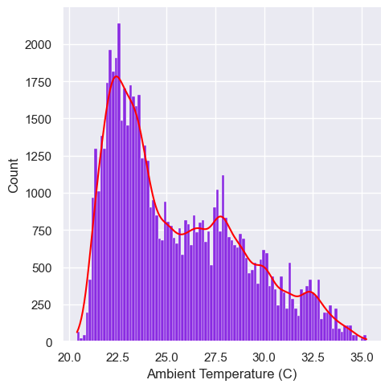

```python
with warnings.catch_warnings():
    warnings.simplefilter('ignore')
    sns.displot(data = plant1, x = 'AMBIENT_TEMPERATURE', kde=True, bins = 100,color = "red", facecolor = "blueviolet")
    plt.xlabel('Ambient Temperature (C)');
```

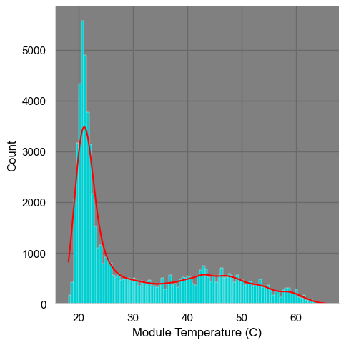

```python
with warnings.catch_warnings():
    warnings.simplefilter('ignore')
    custom_style = {'axes.labelcolor': 'black',
                'xtick.color': 'black',
                'ytick.color': 'black',
               'axes.facecolor': 'gray',
               'grid.color': 'dimgray'}
    sns.set_style("whitegrid", rc=custom_style)

    sns.displot(data = plant1, x = 'MODULE_TEMPERATURE', kde=True, bins = 100,
                color = "red", facecolor = "darkturquoise")
    plt.xlabel('Module Temperature (C)');
```

### Inverters and their Total Contributions to Power Output

```python
inverter = plant1.copy()
inverter = inverter[inverter['DATE_STRING'] == '2020-06-17']
inverter = inverter[inverter['TIME'] == '23:45:00']
```

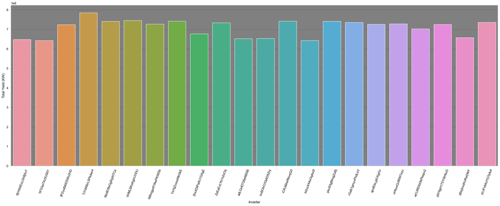

```python
plt.figure(figsize=(30,10))
sns.barplot(data = inverter, x = 'SOURCE_KEY_x', y = 'TOTAL_YIELD')
plt.xlabel('Inverter')
plt.ylabel('Total Yield (KW)')
plt.xticks(rotation=70);
```